# Elsevier 2022 SDG mapping

# General to all SDGs

## Introduction

The United Nations Sustainable Development Goals (SDGs) challenge the global community to build a world where no one is left behind.

Since 2018, Elsevier has generated SDG search queries to help researchers and institutions track and demonstrate progress toward the SDG targets. In the past 3 years, these queries, along with the university’s own data and evidence supporting progress and contributions to the particular SDG outside of research-based metrics, are used for the THE Impact Rankings.

## Method

For 2022, this SDG uses the exact same search query and ML algorithm as the Elsevier 2021 SDG mapping. [Full details of the 2021 methodology are available on Digital Commons Data.](https://elsevier.digitalcommonsdata.com/datasets/9sxdykm8s4/4)

# [SDG 14 - Conserve and sustainably use the oceans, seas and marine resources for sustainable development](https://sdgs.un.org/goals/goal14)

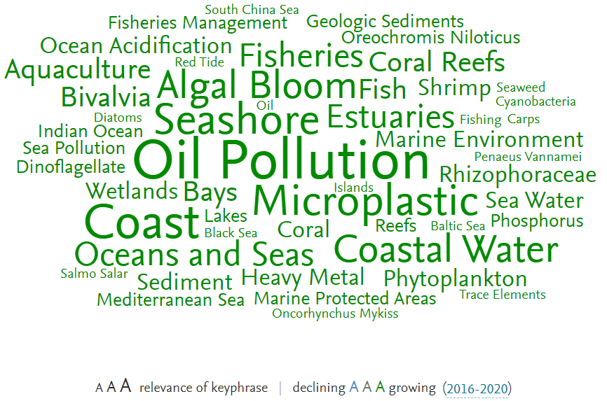

Explore this wordcloud plus the most active contributors on the [SciVal SDG site](https://scival.com/sdg)

## Query

Below is the full search query used for this SDG. We’ve broken it down by each query component. Use the + and – to concatenate the different bracket levels.

(

(

(

(

((TITLE-ABS("Angola") OR TITLE-ABS("Antigua and Barbuda") OR TITLE-ABS("Aruba") OR TITLE-ABS("Bahamas") OR TITLE-ABS("Bangladesh") OR TITLE-ABS("Barbados") OR TITLE-ABS("Belize") OR TITLE-ABS("Benin") OR TITLE-ABS("British Virgin Islands") OR TITLE-ABS("Cambodia") OR TITLE-ABS("Cape Verde") OR TITLE-ABS("Cayman Islands") OR TITLE-ABS("Comoros") OR TITLE-ABS("Cook Islands") OR TITLE-ABS("Cuba") OR TITLE-ABS("Curaçao") OR TITLE-ABS("Democratic Republic of the Congo") OR TITLE-ABS("Djibouti") OR TITLE-ABS("Dominica") OR TITLE-ABS("Dominican Republic") OR TITLE-ABS("Equatorial Guinea") OR TITLE-ABS("Eritrea") OR TITLE-ABS("Federated States of Micronesia") OR TITLE-ABS("Fiji") OR TITLE-ABS("Gambia") OR TITLE-ABS("Grenada") OR TITLE-ABS("Guinea") OR TITLE-ABS("Guinea-Bissau") OR TITLE-ABS("Guyana") OR TITLE-ABS("Haiti") OR TITLE-ABS("Jamaica") OR TITLE-ABS("Kiribati") OR TITLE-ABS("Liberia") OR TITLE-ABS("Madagascar") OR TITLE-ABS("Maldives") OR TITLE-ABS("Marshall Islands") OR TITLE-ABS("Mauritania") OR TITLE-ABS("Mauritius") OR TITLE-ABS("Montserrat") OR TITLE-ABS("Mozambique") OR TITLE-ABS("Myanmar") OR TITLE-ABS("Nauru") OR TITLE-ABS("New Caledonia") OR TITLE-ABS("Niue") OR TITLE-ABS("Palau") OR TITLE-ABS("Papua New Guinea") OR TITLE-ABS("Saint Kitts and Nevis") OR TITLE-ABS("Saint Lucia") OR TITLE-ABS("Saint Vincent and the Grenadines") OR TITLE-ABS("Samoa") OR TITLE-ABS("Sao Tome and Principe") OR TITLE-ABS("São Tomé and Principe") OR TITLE-ABS("Senegal") OR TITLE-ABS("Seychelles") OR TITLE-ABS("Sierra Leone") OR TITLE-ABS("Singapore") OR TITLE-ABS("Sint Maarten") OR TITLE-ABS("Solomon Islands") OR TITLE-ABS("Somalia") OR TITLE-ABS("St. Kitts and Nevis") OR TITLE-ABS("St. Lucia") OR TITLE-ABS("St. Vincent and the Grenadines") OR TITLE-ABS("Sudan") OR TITLE-ABS("Suriname") OR TITLE-ABS("Timor-Leste") OR TITLE-ABS("Timor-Lesté") OR TITLE-ABS("Togo") OR TITLE-ABS("Tokelau") OR TITLE-ABS("Tonga") OR TITLE-ABS("Trinidad and Tobago") OR TITLE-ABS("Tuvalu") OR TITLE-ABS("United Republic of Tanzania") OR TITLE-ABS("Vanuatu") OR TITLE-ABS("Yemen") OR TITLE-ABS("Small Island Developing State") OR TITLE-ABS("Small Island Developing State") OR TITLE-ABS("Island Developing State") OR TITLE-ABS("Island Developing States") OR TITLE-ABS("Least Developed Country") OR TITLE-ABS("Least Developed Countries")) AND TITLE-ABS("shrimp farming")) OR ((TITLE-ABS("Angola") OR TITLE-ABS("Antigua and Barbuda") OR TITLE-ABS("Aruba") OR TITLE-ABS("Bahamas") OR TITLE-ABS("Bangladesh") OR TITLE-ABS("Barbados") OR TITLE-ABS("Belize") OR TITLE-ABS("Benin") OR TITLE-ABS("British Virgin Islands") OR TITLE-ABS("Cambodia") OR TITLE-ABS("Cape Verde") OR TITLE-ABS("Cayman Islands") OR TITLE-ABS("Comoros") OR TITLE-ABS("Cook Islands") OR TITLE-ABS("Cuba") OR TITLE-ABS("Curaçao") OR TITLE-ABS("Democratic Republic of the Congo") OR TITLE-ABS("Djibouti") OR TITLE-ABS("Dominica") OR TITLE-ABS("Dominican Republic") OR TITLE-ABS("Equatorial Guinea") OR TITLE-ABS("Eritrea") OR TITLE-ABS("Federated States of Micronesia") OR TITLE-ABS("Fiji") OR TITLE-ABS("Gambia") OR TITLE-ABS("Grenada") OR TITLE-ABS("Guinea") OR TITLE-ABS("GuineaBissau") OR TITLE-ABS("Guyana") OR TITLE-ABS("Haiti") OR TITLE-ABS("Jamaica") OR TITLE-ABS("Kiribati") OR TITLE-ABS("Liberia") OR TITLE-ABS("Madagascar") OR TITLE-ABS("Maldives") OR TITLE-ABS("Marshall Islands") OR TITLE-ABS("Mauritania") OR TITLE-ABS("Mauritius") OR TITLE-ABS("Montserrat") OR TITLE-ABS("Mozambique") OR TITLE-ABS("Myanmar") OR TITLE-ABS("Nauru") OR TITLE-ABS("New Caledonia") OR TITLE-ABS("Niue") OR TITLE-ABS("Palau") OR TITLE-ABS("Papua New Guinea") OR TITLE-ABS("Saint Kitts and Nevis") OR TITLE-ABS("Saint Lucia") OR TITLE-ABS("Saint Vincent and the Grenadines") OR TITLE-ABS("Samoa") OR TITLE-ABS("Sao Tome and Principe") OR TITLE-ABS("São Tomé and Principe") OR TITLE-ABS("Senegal") OR TITLE-ABS("Seychelles") OR TITLE-ABS("Sierra Leone") OR TITLE-ABS("Singapore") OR TITLE-ABS("Sint Maarten") OR TITLE-ABS("Solomon Islands") OR TITLE-ABS("Somalia") OR TITLE-ABS("St. Kitts and Nevis") OR TITLE-ABS("St. Lucia") OR TITLE-ABS("St. Vincent and the Grenadines") OR TITLE-ABS("Sudan") OR TITLE-ABS("Suriname") OR TITLE-ABS("TimorLeste") OR TITLE-ABS("TimorLesté") OR TITLE-ABS("Togo") OR TITLE-ABS("Tokelau") OR TITLE-ABS("Tonga") OR TITLE-ABS("Trinidad and Tobago") OR TITLE-ABS("Tuvalu") OR TITLE-ABS("United Republic of Tanzania") OR TITLE-ABS("Vanuatu") OR TITLE-ABS("Yemen") OR TITLE-ABS("Small Island Developing State") OR TITLE-ABS("Small Island Developing State") OR TITLE-ABS("Island Developing State") OR TITLE-ABS("Island Developing States") OR TITLE-ABS("Least Developed Country") OR TITLE-ABS("Least Developed Countries")) AND TITLE-ABS("shrimp farming"))

)

OR

(

((AUTHKEY("Angola") OR AUTHKEY("Antigua and Barbuda") OR AUTHKEY("Aruba") OR AUTHKEY("Bahamas") OR AUTHKEY("Bangladesh") OR AUTHKEY("Barbados") OR AUTHKEY("Belize") OR AUTHKEY("Benin") OR AUTHKEY("British Virgin Islands") OR AUTHKEY("Cambodia") OR AUTHKEY("Cape Verde") OR AUTHKEY("Cayman Islands") OR AUTHKEY("Comoros") OR AUTHKEY("Cook Islands") OR AUTHKEY("Cuba") OR AUTHKEY("Curaçao") OR AUTHKEY("Democratic Republic of the Congo") OR AUTHKEY("Djibouti") OR AUTHKEY("Dominica") OR AUTHKEY("Dominican Republic") OR AUTHKEY("Equatorial Guinea") OR AUTHKEY("Eritrea") OR AUTHKEY("Federated States of Micronesia") OR AUTHKEY("Fiji") OR AUTHKEY("Gambia") OR AUTHKEY("Grenada") OR AUTHKEY("Guinea") OR AUTHKEY("Guinea-Bissau") OR AUTHKEY("Guyana") OR AUTHKEY("Haiti") OR AUTHKEY("Jamaica") OR AUTHKEY("Kiribati") OR AUTHKEY("Liberia") OR AUTHKEY("Madagascar") OR AUTHKEY("Maldives") OR AUTHKEY("Marshall Islands") OR AUTHKEY("Mauritania") OR AUTHKEY("Mauritius") OR AUTHKEY("Montserrat") OR AUTHKEY("Mozambique") OR AUTHKEY("Myanmar") OR AUTHKEY("Nauru") OR AUTHKEY("New Caledonia") OR AUTHKEY("Niue") OR AUTHKEY("Palau") OR AUTHKEY("Papua New Guinea") OR AUTHKEY("Saint Kitts and Nevis") OR AUTHKEY("Saint Lucia") OR AUTHKEY("Saint Vincent and the Grenadines") OR AUTHKEY("Samoa") OR AUTHKEY("Sao Tome and Principe") OR AUTHKEY("São Tomé and Principe") OR AUTHKEY("Senegal") OR AUTHKEY("Seychelles") OR AUTHKEY("Sierra Leone") OR AUTHKEY("Singapore") OR AUTHKEY("Sint Maarten") OR AUTHKEY("Solomon Islands") OR AUTHKEY("Somalia") OR AUTHKEY("St. Kitts and Nevis") OR AUTHKEY("St. Lucia") OR AUTHKEY("St. Vincent and the Grenadines") OR AUTHKEY("Sudan") OR AUTHKEY("Suriname") OR AUTHKEY("Timor-Leste") OR AUTHKEY("Timor-Lesté") OR AUTHKEY("Togo") OR AUTHKEY("Tokelau") OR AUTHKEY("Tonga") OR AUTHKEY("Trinidad and Tobago") OR AUTHKEY("Tuvalu") OR AUTHKEY("United Republic of Tanzania") OR AUTHKEY("Vanuatu") OR AUTHKEY("Yemen") OR AUTHKEY("Small Island Developing State") OR AUTHKEY("Small Island Developing State") OR AUTHKEY("Island Developing State") OR AUTHKEY("Island Developing States") OR AUTHKEY("Least Developed Country") OR AUTHKEY("Least Developed Countries")) AND AUTHKEY("shrimp farming")) OR ((AUTHKEY("Angola") OR AUTHKEY("Antigua and Barbuda") OR AUTHKEY("Aruba") OR AUTHKEY("Bahamas") OR AUTHKEY("Bangladesh") OR AUTHKEY("Barbados") OR AUTHKEY("Belize") OR AUTHKEY("Benin") OR AUTHKEY("British Virgin Islands") OR AUTHKEY("Cambodia") OR AUTHKEY("Cape Verde") OR AUTHKEY("Cayman Islands") OR AUTHKEY("Comoros") OR AUTHKEY("Cook Islands") OR AUTHKEY("Cuba") OR AUTHKEY("Curaçao") OR AUTHKEY("Democratic Republic of the Congo") OR AUTHKEY("Djibouti") OR AUTHKEY("Dominica") OR AUTHKEY("Dominican Republic") OR AUTHKEY("Equatorial Guinea") OR AUTHKEY("Eritrea") OR AUTHKEY("Federated States of Micronesia") OR AUTHKEY("Fiji") OR AUTHKEY("Gambia") OR AUTHKEY("Grenada") OR AUTHKEY("Guinea") OR AUTHKEY("GuineaBissau") OR AUTHKEY("Guyana") OR AUTHKEY("Haiti") OR AUTHKEY("Jamaica") OR AUTHKEY("Kiribati") OR AUTHKEY("Liberia") OR AUTHKEY("Madagascar") OR AUTHKEY("Maldives") OR AUTHKEY("Marshall Islands") OR AUTHKEY("Mauritania") OR AUTHKEY("Mauritius") OR AUTHKEY("Montserrat") OR AUTHKEY("Mozambique") OR AUTHKEY("Myanmar") OR AUTHKEY("Nauru") OR AUTHKEY("New Caledonia") OR AUTHKEY("Niue") OR AUTHKEY("Palau") OR AUTHKEY("Papua New Guinea") OR AUTHKEY("Saint Kitts and Nevis") OR AUTHKEY("Saint Lucia") OR AUTHKEY("Saint Vincent and the Grenadines") OR AUTHKEY("Samoa") OR AUTHKEY("Sao Tome and Principe") OR AUTHKEY("São Tomé and Principe") OR AUTHKEY("Senegal") OR AUTHKEY("Seychelles") OR AUTHKEY("Sierra Leone") OR AUTHKEY("Singapore") OR AUTHKEY("Sint Maarten") OR AUTHKEY("Solomon Islands") OR AUTHKEY("Somalia") OR AUTHKEY("St. Kitts and Nevis") OR AUTHKEY("St. Lucia") OR AUTHKEY("St. Vincent and the Grenadines") OR AUTHKEY("Sudan") OR AUTHKEY("Suriname") OR AUTHKEY("TimorLeste") OR AUTHKEY("TimorLesté") OR AUTHKEY("Togo") OR AUTHKEY("Tokelau") OR AUTHKEY("Tonga") OR AUTHKEY("Trinidad and Tobago") OR AUTHKEY("Tuvalu") OR AUTHKEY("United Republic of Tanzania") OR AUTHKEY("Vanuatu") OR AUTHKEY("Yemen") OR AUTHKEY("Small Island Developing State") OR AUTHKEY("Small Island Developing State") OR AUTHKEY("Island Developing State") OR AUTHKEY("Island Developing States") OR AUTHKEY("Least Developed Country") OR AUTHKEY("Least Developed Countries")) AND AUTHKEY("shrimp farming"))

)

OR

(

((TITLE-ABS("Angola") OR TITLE-ABS("Antigua and Barbuda") OR TITLE-ABS("Aruba") OR TITLE-ABS("Bahamas") OR TITLE-ABS("Bangladesh") OR TITLE-ABS("Barbados") OR TITLE-ABS("Belize") OR TITLE-ABS("Benin") OR TITLE-ABS("British Virgin Islands") OR TITLE-ABS("Cambodia") OR TITLE-ABS("Cape Verde") OR TITLE-ABS("Cayman Islands") OR TITLE-ABS("Comoros") OR TITLE-ABS("Cook Islands") OR TITLE-ABS("Cuba") OR TITLE-ABS("Curaçao") OR TITLE-ABS("Democratic Republic of the Congo") OR TITLE-ABS("Djibouti") OR TITLE-ABS("Dominica") OR TITLE-ABS("Dominican Republic") OR TITLE-ABS("Equatorial Guinea") OR TITLE-ABS("Eritrea") OR TITLE-ABS("Federated States of Micronesia") OR TITLE-ABS("Fiji") OR TITLE-ABS("Gambia") OR TITLE-ABS("Grenada") OR TITLE-ABS("Guinea") OR TITLE-ABS("Guinea-Bissau") OR TITLE-ABS("Guyana") OR TITLE-ABS("Haiti") OR TITLE-ABS("Jamaica") OR TITLE-ABS("Kiribati") OR TITLE-ABS("Liberia") OR TITLE-ABS("Madagascar") OR TITLE-ABS("Maldives") OR TITLE-ABS("Marshall Islands") OR TITLE-ABS("Mauritania") OR TITLE-ABS("Mauritius") OR TITLE-ABS("Montserrat") OR TITLE-ABS("Mozambique") OR TITLE-ABS("Myanmar") OR TITLE-ABS("Nauru") OR TITLE-ABS("New Caledonia") OR TITLE-ABS("Niue") OR TITLE-ABS("Palau") OR TITLE-ABS("Papua New Guinea") OR TITLE-ABS("Saint Kitts and Nevis") OR TITLE-ABS("Saint Lucia") OR TITLE-ABS("Saint Vincent and the Grenadines") OR TITLE-ABS("Samoa") OR TITLE-ABS("Sao Tome and Principe") OR TITLE-ABS("São Tomé and Principe") OR TITLE-ABS("Senegal") OR TITLE-ABS("Seychelles") OR TITLE-ABS("Sierra Leone") OR TITLE-ABS("Singapore") OR TITLE-ABS("Sint Maarten") OR TITLE-ABS("Solomon Islands") OR TITLE-ABS("Somalia") OR TITLE-ABS("St. Kitts and Nevis") OR TITLE-ABS("St. Lucia") OR TITLE-ABS("St. Vincent and the Grenadines") OR TITLE-ABS("Sudan") OR TITLE-ABS("Suriname") OR TITLE-ABS("Timor-Leste") OR TITLE-ABS("Timor-Lesté") OR TITLE-ABS("Togo") OR TITLE-ABS("Tokelau") OR TITLE-ABS("Tonga") OR TITLE-ABS("Trinidad and Tobago") OR TITLE-ABS("Tuvalu") OR TITLE-ABS("United Republic of Tanzania") OR TITLE-ABS("Vanuatu") OR TITLE-ABS("Yemen") OR TITLE-ABS("Small Island Developing State") OR TITLE-ABS("Small Island Developing State") OR TITLE-ABS("Island Developing State") OR TITLE-ABS("Island Developing States") OR TITLE-ABS("Least Developed Country") OR TITLE-ABS("Least Developed Countries")) AND TITLE-ABS("fish farm")) OR ((TITLE-ABS("Angola") OR TITLE-ABS("Antigua and Barbuda") OR TITLE-ABS("Aruba") OR TITLE-ABS("Bahamas") OR TITLE-ABS("Bangladesh") OR TITLE-ABS("Barbados") OR TITLE-ABS("Belize") OR TITLE-ABS("Benin") OR TITLE-ABS("British Virgin Islands") OR TITLE-ABS("Cambodia") OR TITLE-ABS("Cape Verde") OR TITLE-ABS("Cayman Islands") OR TITLE-ABS("Comoros") OR TITLE-ABS("Cook Islands") OR TITLE-ABS("Cuba") OR TITLE-ABS("Curaçao") OR TITLE-ABS("Democratic Republic of the Congo") OR TITLE-ABS("Djibouti") OR TITLE-ABS("Dominica") OR TITLE-ABS("Dominican Republic") OR TITLE-ABS("Equatorial Guinea") OR TITLE-ABS("Eritrea") OR TITLE-ABS("Federated States of Micronesia") OR TITLE-ABS("Fiji") OR TITLE-ABS("Gambia") OR TITLE-ABS("Grenada") OR TITLE-ABS("Guinea") OR TITLE-ABS("GuineaBissau") OR TITLE-ABS("Guyana") OR TITLE-ABS("Haiti") OR TITLE-ABS("Jamaica") OR TITLE-ABS("Kiribati") OR TITLE-ABS("Liberia") OR TITLE-ABS("Madagascar") OR TITLE-ABS("Maldives") OR TITLE-ABS("Marshall Islands") OR TITLE-ABS("Mauritania") OR TITLE-ABS("Mauritius") OR TITLE-ABS("Montserrat") OR TITLE-ABS("Mozambique") OR TITLE-ABS("Myanmar") OR TITLE-ABS("Nauru") OR TITLE-ABS("New Caledonia") OR TITLE-ABS("Niue") OR TITLE-ABS("Palau") OR TITLE-ABS("Papua New Guinea") OR TITLE-ABS("Saint Kitts and Nevis") OR TITLE-ABS("Saint Lucia") OR TITLE-ABS("Saint Vincent and the Grenadines") OR TITLE-ABS("Samoa") OR TITLE-ABS("Sao Tome and Principe") OR TITLE-ABS("São Tomé and Principe") OR TITLE-ABS("Senegal") OR TITLE-ABS("Seychelles") OR TITLE-ABS("Sierra Leone") OR TITLE-ABS("Singapore") OR TITLE-ABS("Sint Maarten") OR TITLE-ABS("Solomon Islands") OR TITLE-ABS("Somalia") OR TITLE-ABS("St. Kitts and Nevis") OR TITLE-ABS("St. Lucia") OR TITLE-ABS("St. Vincent and the Grenadines") OR TITLE-ABS("Sudan") OR TITLE-ABS("Suriname") OR TITLE-ABS("TimorLeste") OR TITLE-ABS("TimorLesté") OR TITLE-ABS("Togo") OR TITLE-ABS("Tokelau") OR TITLE-ABS("Tonga") OR TITLE-ABS("Trinidad and Tobago") OR TITLE-ABS("Tuvalu") OR TITLE-ABS("United Republic of Tanzania") OR TITLE-ABS("Vanuatu") OR TITLE-ABS("Yemen") OR TITLE-ABS("Small Island Developing State") OR TITLE-ABS("Small Island Developing State") OR TITLE-ABS("Island Developing State") OR TITLE-ABS("Island Developing States") OR TITLE-ABS("Least Developed Country") OR TITLE-ABS("Least Developed Countries")) AND TITLE-ABS("fish farm"))

)

OR

(

((AUTHKEY("Angola") OR AUTHKEY("Antigua and Barbuda") OR AUTHKEY("Aruba") OR AUTHKEY("Bahamas") OR AUTHKEY("Bangladesh") OR AUTHKEY("Barbados") OR AUTHKEY("Belize") OR AUTHKEY("Benin") OR AUTHKEY("British Virgin Islands") OR AUTHKEY("Cambodia") OR AUTHKEY("Cape Verde") OR AUTHKEY("Cayman Islands") OR AUTHKEY("Comoros") OR AUTHKEY("Cook Islands") OR AUTHKEY("Cuba") OR AUTHKEY("Curaçao") OR AUTHKEY("Democratic Republic of the Congo") OR AUTHKEY("Djibouti") OR AUTHKEY("Dominica") OR AUTHKEY("Dominican Republic") OR AUTHKEY("Equatorial Guinea") OR AUTHKEY("Eritrea") OR AUTHKEY("Federated States of Micronesia") OR AUTHKEY("Fiji") OR AUTHKEY("Gambia") OR AUTHKEY("Grenada") OR AUTHKEY("Guinea") OR AUTHKEY("Guinea-Bissau") OR AUTHKEY("Guyana") OR AUTHKEY("Haiti") OR AUTHKEY("Jamaica") OR AUTHKEY("Kiribati") OR AUTHKEY("Liberia") OR AUTHKEY("Madagascar") OR AUTHKEY("Maldives") OR AUTHKEY("Marshall Islands") OR AUTHKEY("Mauritania") OR AUTHKEY("Mauritius") OR AUTHKEY("Montserrat") OR AUTHKEY("Mozambique") OR AUTHKEY("Myanmar") OR AUTHKEY("Nauru") OR AUTHKEY("New Caledonia") OR AUTHKEY("Niue") OR AUTHKEY("Palau") OR AUTHKEY("Papua New Guinea") OR AUTHKEY("Saint Kitts and Nevis") OR AUTHKEY("Saint Lucia") OR AUTHKEY("Saint Vincent and the Grenadines") OR AUTHKEY("Samoa") OR AUTHKEY("Sao Tome and Principe") OR AUTHKEY("São Tomé and Principe") OR AUTHKEY("Senegal") OR AUTHKEY("Seychelles") OR AUTHKEY("Sierra Leone") OR AUTHKEY("Singapore") OR AUTHKEY("Sint Maarten") OR AUTHKEY("Solomon Islands") OR AUTHKEY("Somalia") OR AUTHKEY("St. Kitts and Nevis") OR AUTHKEY("St. Lucia") OR AUTHKEY("St. Vincent and the Grenadines") OR AUTHKEY("Sudan") OR AUTHKEY("Suriname") OR AUTHKEY("Timor-Leste") OR AUTHKEY("Timor-Lesté") OR AUTHKEY("Togo") OR AUTHKEY("Tokelau") OR AUTHKEY("Tonga") OR AUTHKEY("Trinidad and Tobago") OR AUTHKEY("Tuvalu") OR AUTHKEY("United Republic of Tanzania") OR AUTHKEY("Vanuatu") OR AUTHKEY("Yemen") OR AUTHKEY("Small Island Developing State") OR AUTHKEY("Small Island Developing State") OR AUTHKEY("Island Developing State") OR AUTHKEY("Island Developing States") OR AUTHKEY("Least Developed Country") OR AUTHKEY("Least Developed Countries")) AND AUTHKEY("fish farm")) OR ((AUTHKEY("Angola") OR AUTHKEY("Antigua and Barbuda") OR AUTHKEY("Aruba") OR AUTHKEY("Bahamas") OR AUTHKEY("Bangladesh") OR AUTHKEY("Barbados") OR AUTHKEY("Belize") OR AUTHKEY("Benin") OR AUTHKEY("British Virgin Islands") OR AUTHKEY("Cambodia") OR AUTHKEY("Cape Verde") OR AUTHKEY("Cayman Islands") OR AUTHKEY("Comoros") OR AUTHKEY("Cook Islands") OR AUTHKEY("Cuba") OR AUTHKEY("Curaçao") OR AUTHKEY("Democratic Republic of the Congo") OR AUTHKEY("Djibouti") OR AUTHKEY("Dominica") OR AUTHKEY("Dominican Republic") OR AUTHKEY("Equatorial Guinea") OR AUTHKEY("Eritrea") OR AUTHKEY("Federated States of Micronesia") OR AUTHKEY("Fiji") OR AUTHKEY("Gambia") OR AUTHKEY("Grenada") OR AUTHKEY("Guinea") OR AUTHKEY("GuineaBissau") OR AUTHKEY("Guyana") OR AUTHKEY("Haiti") OR AUTHKEY("Jamaica") OR AUTHKEY("Kiribati") OR AUTHKEY("Liberia") OR AUTHKEY("Madagascar") OR AUTHKEY("Maldives") OR AUTHKEY("Marshall Islands") OR AUTHKEY("Mauritania") OR AUTHKEY("Mauritius") OR AUTHKEY("Montserrat") OR AUTHKEY("Mozambique") OR AUTHKEY("Myanmar") OR AUTHKEY("Nauru") OR AUTHKEY("New Caledonia") OR AUTHKEY("Niue") OR AUTHKEY("Palau") OR AUTHKEY("Papua New Guinea") OR AUTHKEY("Saint Kitts and Nevis") OR AUTHKEY("Saint Lucia") OR AUTHKEY("Saint Vincent and the Grenadines") OR AUTHKEY("Samoa") OR AUTHKEY("Sao Tome and Principe") OR AUTHKEY("São Tomé and Principe") OR AUTHKEY("Senegal") OR AUTHKEY("Seychelles") OR AUTHKEY("Sierra Leone") OR AUTHKEY("Singapore") OR AUTHKEY("Sint Maarten") OR AUTHKEY("Solomon Islands") OR AUTHKEY("Somalia") OR AUTHKEY("St. Kitts and Nevis") OR AUTHKEY("St. Lucia") OR AUTHKEY("St. Vincent and the Grenadines") OR AUTHKEY("Sudan") OR AUTHKEY("Suriname") OR AUTHKEY("TimorLeste") OR AUTHKEY("TimorLesté") OR AUTHKEY("Togo") OR AUTHKEY("Tokelau") OR AUTHKEY("Tonga") OR AUTHKEY("Trinidad and Tobago") OR AUTHKEY("Tuvalu") OR AUTHKEY("United Republic of Tanzania") OR AUTHKEY("Vanuatu") OR AUTHKEY("Yemen") OR AUTHKEY("Small Island Developing State") OR AUTHKEY("Small Island Developing State") OR AUTHKEY("Island Developing State") OR AUTHKEY("Island Developing States") OR AUTHKEY("Least Developed Country") OR AUTHKEY("Least Developed Countries")) AND AUTHKEY("fish farm"))

)

OR

(

((TITLE-ABS("Angola") OR TITLE-ABS("Antigua and Barbuda") OR TITLE-ABS("Aruba") OR TITLE-ABS("Bahamas") OR TITLE-ABS("Bangladesh") OR TITLE-ABS("Barbados") OR TITLE-ABS("Belize") OR TITLE-ABS("Benin") OR TITLE-ABS("British Virgin Islands") OR TITLE-ABS("Cambodia") OR TITLE-ABS("Cape Verde") OR TITLE-ABS("Cayman Islands") OR TITLE-ABS("Comoros") OR TITLE-ABS("Cook Islands") OR TITLE-ABS("Cuba") OR TITLE-ABS("Curaçao") OR TITLE-ABS("Democratic Republic of the Congo") OR TITLE-ABS("Djibouti") OR TITLE-ABS("Dominica") OR TITLE-ABS("Dominican Republic") OR TITLE-ABS("Equatorial Guinea") OR TITLE-ABS("Eritrea") OR TITLE-ABS("Federated States of Micronesia") OR TITLE-ABS("Fiji") OR TITLE-ABS("Gambia") OR TITLE-ABS("Grenada") OR TITLE-ABS("Guinea") OR TITLE-ABS("Guinea-Bissau") OR TITLE-ABS("Guyana") OR TITLE-ABS("Haiti") OR TITLE-ABS("Jamaica") OR TITLE-ABS("Kiribati") OR TITLE-ABS("Liberia") OR TITLE-ABS("Madagascar") OR TITLE-ABS("Maldives") OR TITLE-ABS("Marshall Islands") OR TITLE-ABS("Mauritania") OR TITLE-ABS("Mauritius") OR TITLE-ABS("Montserrat") OR TITLE-ABS("Mozambique") OR TITLE-ABS("Myanmar") OR TITLE-ABS("Nauru") OR TITLE-ABS("New Caledonia") OR TITLE-ABS("Niue") OR TITLE-ABS("Palau") OR TITLE-ABS("Papua New Guinea") OR TITLE-ABS("Saint Kitts and Nevis") OR TITLE-ABS("Saint Lucia") OR TITLE-ABS("Saint Vincent and the Grenadines") OR TITLE-ABS("Samoa") OR TITLE-ABS("Sao Tome and Principe") OR TITLE-ABS("São Tomé and Principe") OR TITLE-ABS("Senegal") OR TITLE-ABS("Seychelles") OR TITLE-ABS("Sierra Leone") OR TITLE-ABS("Singapore") OR TITLE-ABS("Sint Maarten") OR TITLE-ABS("Solomon Islands") OR TITLE-ABS("Somalia") OR TITLE-ABS("St. Kitts and Nevis") OR TITLE-ABS("St. Lucia") OR TITLE-ABS("St. Vincent and the Grenadines") OR TITLE-ABS("Sudan") OR TITLE-ABS("Suriname") OR TITLE-ABS("Timor-Leste") OR TITLE-ABS("Timor-Lesté") OR TITLE-ABS("Togo") OR TITLE-ABS("Tokelau") OR TITLE-ABS("Tonga") OR TITLE-ABS("Trinidad and Tobago") OR TITLE-ABS("Tuvalu") OR TITLE-ABS("United Republic of Tanzania") OR TITLE-ABS("Vanuatu") OR TITLE-ABS("Yemen") OR TITLE-ABS("Small Island Developing State") OR TITLE-ABS("Small Island Developing State") OR TITLE-ABS("Island Developing State") OR TITLE-ABS("Island Developing States") OR TITLE-ABS("Least Developed Country") OR TITLE-ABS("Least Developed Countries")) AND TITLE-ABS("maritime transport")) OR ((TITLE-ABS("Angola") OR TITLE-ABS("Antigua and Barbuda") OR TITLE-ABS("Aruba") OR TITLE-ABS("Bahamas") OR TITLE-ABS("Bangladesh") OR TITLE-ABS("Barbados") OR TITLE-ABS("Belize") OR TITLE-ABS("Benin") OR TITLE-ABS("British Virgin Islands") OR TITLE-ABS("Cambodia") OR TITLE-ABS("Cape Verde") OR TITLE-ABS("Cayman Islands") OR TITLE-ABS("Comoros") OR TITLE-ABS("Cook Islands") OR TITLE-ABS("Cuba") OR TITLE-ABS("Curaçao") OR TITLE-ABS("Democratic Republic of the Congo") OR TITLE-ABS("Djibouti") OR TITLE-ABS("Dominica") OR TITLE-ABS("Dominican Republic") OR TITLE-ABS("Equatorial Guinea") OR TITLE-ABS("Eritrea") OR TITLE-ABS("Federated States of Micronesia") OR TITLE-ABS("Fiji") OR TITLE-ABS("Gambia") OR TITLE-ABS("Grenada") OR TITLE-ABS("Guinea") OR TITLE-ABS("GuineaBissau") OR TITLE-ABS("Guyana") OR TITLE-ABS("Haiti") OR TITLE-ABS("Jamaica") OR TITLE-ABS("Kiribati") OR TITLE-ABS("Liberia") OR TITLE-ABS("Madagascar") OR TITLE-ABS("Maldives") OR TITLE-ABS("Marshall Islands") OR TITLE-ABS("Mauritania") OR TITLE-ABS("Mauritius") OR TITLE-ABS("Montserrat") OR TITLE-ABS("Mozambique") OR TITLE-ABS("Myanmar") OR TITLE-ABS("Nauru") OR TITLE-ABS("New Caledonia") OR TITLE-ABS("Niue") OR TITLE-ABS("Palau") OR TITLE-ABS("Papua New Guinea") OR TITLE-ABS("Saint Kitts and Nevis") OR TITLE-ABS("Saint Lucia") OR TITLE-ABS("Saint Vincent and the Grenadines") OR TITLE-ABS("Samoa") OR TITLE-ABS("Sao Tome and Principe") OR TITLE-ABS("São Tomé and Principe") OR TITLE-ABS("Senegal") OR TITLE-ABS("Seychelles") OR TITLE-ABS("Sierra Leone") OR TITLE-ABS("Singapore") OR TITLE-ABS("Sint Maarten") OR TITLE-ABS("Solomon Islands") OR TITLE-ABS("Somalia") OR TITLE-ABS("St. Kitts and Nevis") OR TITLE-ABS("St. Lucia") OR TITLE-ABS("St. Vincent and the Grenadines") OR TITLE-ABS("Sudan") OR TITLE-ABS("Suriname") OR TITLE-ABS("TimorLeste") OR TITLE-ABS("TimorLesté") OR TITLE-ABS("Togo") OR TITLE-ABS("Tokelau") OR TITLE-ABS("Tonga") OR TITLE-ABS("Trinidad and Tobago") OR TITLE-ABS("Tuvalu") OR TITLE-ABS("United Republic of Tanzania") OR TITLE-ABS("Vanuatu") OR TITLE-ABS("Yemen") OR TITLE-ABS("Small Island Developing State") OR TITLE-ABS("Small Island Developing State") OR TITLE-ABS("Island Developing State") OR TITLE-ABS("Island Developing States") OR TITLE-ABS("Least Developed Country") OR TITLE-ABS("Least Developed Countries")) AND TITLE-ABS("maritime transport"))

)

OR

(

((AUTHKEY("Angola") OR AUTHKEY("Antigua and Barbuda") OR AUTHKEY("Aruba") OR AUTHKEY("Bahamas") OR AUTHKEY("Bangladesh") OR AUTHKEY("Barbados") OR AUTHKEY("Belize") OR AUTHKEY("Benin") OR AUTHKEY("British Virgin Islands") OR AUTHKEY("Cambodia") OR AUTHKEY("Cape Verde") OR AUTHKEY("Cayman Islands") OR AUTHKEY("Comoros") OR AUTHKEY("Cook Islands") OR AUTHKEY("Cuba") OR AUTHKEY("Curaçao") OR AUTHKEY("Democratic Republic of the Congo") OR AUTHKEY("Djibouti") OR AUTHKEY("Dominica") OR AUTHKEY("Dominican Republic") OR AUTHKEY("Equatorial Guinea") OR AUTHKEY("Eritrea") OR AUTHKEY("Federated States of Micronesia") OR AUTHKEY("Fiji") OR AUTHKEY("Gambia") OR AUTHKEY("Grenada") OR AUTHKEY("Guinea") OR AUTHKEY("Guinea-Bissau") OR AUTHKEY("Guyana") OR AUTHKEY("Haiti") OR AUTHKEY("Jamaica") OR AUTHKEY("Kiribati") OR AUTHKEY("Liberia") OR AUTHKEY("Madagascar") OR AUTHKEY("Maldives") OR AUTHKEY("Marshall Islands") OR AUTHKEY("Mauritania") OR AUTHKEY("Mauritius") OR AUTHKEY("Montserrat") OR AUTHKEY("Mozambique") OR AUTHKEY("Myanmar") OR AUTHKEY("Nauru") OR AUTHKEY("New Caledonia") OR AUTHKEY("Niue") OR AUTHKEY("Palau") OR AUTHKEY("Papua New Guinea") OR AUTHKEY("Saint Kitts and Nevis") OR AUTHKEY("Saint Lucia") OR AUTHKEY("Saint Vincent and the Grenadines") OR AUTHKEY("Samoa") OR AUTHKEY("Sao Tome and Principe") OR AUTHKEY("São Tomé and Principe") OR AUTHKEY("Senegal") OR AUTHKEY("Seychelles") OR AUTHKEY("Sierra Leone") OR AUTHKEY("Singapore") OR AUTHKEY("Sint Maarten") OR AUTHKEY("Solomon Islands") OR AUTHKEY("Somalia") OR AUTHKEY("St. Kitts and Nevis") OR AUTHKEY("St. Lucia") OR AUTHKEY("St. Vincent and the Grenadines") OR AUTHKEY("Sudan") OR AUTHKEY("Suriname") OR AUTHKEY("Timor-Leste") OR AUTHKEY("Timor-Lesté") OR AUTHKEY("Togo") OR AUTHKEY("Tokelau") OR AUTHKEY("Tonga") OR AUTHKEY("Trinidad and Tobago") OR AUTHKEY("Tuvalu") OR AUTHKEY("United Republic of Tanzania") OR AUTHKEY("Vanuatu") OR AUTHKEY("Yemen") OR AUTHKEY("Small Island Developing State") OR AUTHKEY("Small Island Developing State") OR AUTHKEY("Island Developing State") OR AUTHKEY("Island Developing States") OR AUTHKEY("Least Developed Country") OR AUTHKEY("Least Developed Countries")) AND AUTHKEY("maritime transport")) OR ((AUTHKEY("Angola") OR AUTHKEY("Antigua and Barbuda") OR AUTHKEY("Aruba") OR AUTHKEY("Bahamas") OR AUTHKEY("Bangladesh") OR AUTHKEY("Barbados") OR AUTHKEY("Belize") OR AUTHKEY("Benin") OR AUTHKEY("British Virgin Islands") OR AUTHKEY("Cambodia") OR AUTHKEY("Cape Verde") OR AUTHKEY("Cayman Islands") OR AUTHKEY("Comoros") OR AUTHKEY("Cook Islands") OR AUTHKEY("Cuba") OR AUTHKEY("Curaçao") OR AUTHKEY("Democratic Republic of the Congo") OR AUTHKEY("Djibouti") OR AUTHKEY("Dominica") OR AUTHKEY("Dominican Republic") OR AUTHKEY("Equatorial Guinea") OR AUTHKEY("Eritrea") OR AUTHKEY("Federated States of Micronesia") OR AUTHKEY("Fiji") OR AUTHKEY("Gambia") OR AUTHKEY("Grenada") OR AUTHKEY("Guinea") OR AUTHKEY("GuineaBissau") OR AUTHKEY("Guyana") OR AUTHKEY("Haiti") OR AUTHKEY("Jamaica") OR AUTHKEY("Kiribati") OR AUTHKEY("Liberia") OR AUTHKEY("Madagascar") OR AUTHKEY("Maldives") OR AUTHKEY("Marshall Islands") OR AUTHKEY("Mauritania") OR AUTHKEY("Mauritius") OR AUTHKEY("Montserrat") OR AUTHKEY("Mozambique") OR AUTHKEY("Myanmar") OR AUTHKEY("Nauru") OR AUTHKEY("New Caledonia") OR AUTHKEY("Niue") OR AUTHKEY("Palau") OR AUTHKEY("Papua New Guinea") OR AUTHKEY("Saint Kitts and Nevis") OR AUTHKEY("Saint Lucia") OR AUTHKEY("Saint Vincent and the Grenadines") OR AUTHKEY("Samoa") OR AUTHKEY("Sao Tome and Principe") OR AUTHKEY("São Tomé and Principe") OR AUTHKEY("Senegal") OR AUTHKEY("Seychelles") OR AUTHKEY("Sierra Leone") OR AUTHKEY("Singapore") OR AUTHKEY("Sint Maarten") OR AUTHKEY("Solomon Islands") OR AUTHKEY("Somalia") OR AUTHKEY("St. Kitts and Nevis") OR AUTHKEY("St. Lucia") OR AUTHKEY("St. Vincent and the Grenadines") OR AUTHKEY("Sudan") OR AUTHKEY("Suriname") OR AUTHKEY("TimorLeste") OR AUTHKEY("TimorLesté") OR AUTHKEY("Togo") OR AUTHKEY("Tokelau") OR AUTHKEY("Tonga") OR AUTHKEY("Trinidad and Tobago") OR AUTHKEY("Tuvalu") OR AUTHKEY("United Republic of Tanzania") OR AUTHKEY("Vanuatu") OR AUTHKEY("Yemen") OR AUTHKEY("Small Island Developing State") OR AUTHKEY("Small Island Developing State") OR AUTHKEY("Island Developing State") OR AUTHKEY("Island Developing States") OR AUTHKEY("Least Developed Country") OR AUTHKEY("Least Developed Countries")) AND AUTHKEY("maritime transport"))

)

OR

(

((TITLE-ABS("Angola") OR TITLE-ABS("Antigua and Barbuda") OR TITLE-ABS("Aruba") OR TITLE-ABS("Bahamas") OR TITLE-ABS("Bangladesh") OR TITLE-ABS("Barbados") OR TITLE-ABS("Belize") OR TITLE-ABS("Benin") OR TITLE-ABS("British Virgin Islands") OR TITLE-ABS("Cambodia") OR TITLE-ABS("Cape Verde") OR TITLE-ABS("Cayman Islands") OR TITLE-ABS("Comoros") OR TITLE-ABS("Cook Islands") OR TITLE-ABS("Cuba") OR TITLE-ABS("Curaçao") OR TITLE-ABS("Democratic Republic of the Congo") OR TITLE-ABS("Djibouti") OR TITLE-ABS("Dominica") OR TITLE-ABS("Dominican Republic") OR TITLE-ABS("Equatorial Guinea") OR TITLE-ABS("Eritrea") OR TITLE-ABS("Federated States of Micronesia") OR TITLE-ABS("Fiji") OR TITLE-ABS("Gambia") OR TITLE-ABS("Grenada") OR TITLE-ABS("Guinea") OR TITLE-ABS("Guinea-Bissau") OR TITLE-ABS("Guyana") OR TITLE-ABS("Haiti") OR TITLE-ABS("Jamaica") OR TITLE-ABS("Kiribati") OR TITLE-ABS("Liberia") OR TITLE-ABS("Madagascar") OR TITLE-ABS("Maldives") OR TITLE-ABS("Marshall Islands") OR TITLE-ABS("Mauritania") OR TITLE-ABS("Mauritius") OR TITLE-ABS("Montserrat") OR TITLE-ABS("Mozambique") OR TITLE-ABS("Myanmar") OR TITLE-ABS("Nauru") OR TITLE-ABS("New Caledonia") OR TITLE-ABS("Niue") OR TITLE-ABS("Palau") OR TITLE-ABS("Papua New Guinea") OR TITLE-ABS("Saint Kitts and Nevis") OR TITLE-ABS("Saint Lucia") OR TITLE-ABS("Saint Vincent and the Grenadines") OR TITLE-ABS("Samoa") OR TITLE-ABS("Sao Tome and Principe") OR TITLE-ABS("São Tomé and Principe") OR TITLE-ABS("Senegal") OR TITLE-ABS("Seychelles") OR TITLE-ABS("Sierra Leone") OR TITLE-ABS("Singapore") OR TITLE-ABS("Sint Maarten") OR TITLE-ABS("Solomon Islands") OR TITLE-ABS("Somalia") OR TITLE-ABS("St. Kitts and Nevis") OR TITLE-ABS("St. Lucia") OR TITLE-ABS("St. Vincent and the Grenadines") OR TITLE-ABS("Sudan") OR TITLE-ABS("Suriname") OR TITLE-ABS("Timor-Leste") OR TITLE-ABS("Timor-Lesté") OR TITLE-ABS("Togo") OR TITLE-ABS("Tokelau") OR TITLE-ABS("Tonga") OR TITLE-ABS("Trinidad and Tobago") OR TITLE-ABS("Tuvalu") OR TITLE-ABS("United Republic of Tanzania") OR TITLE-ABS("Vanuatu") OR TITLE-ABS("Yemen") OR TITLE-ABS("Small Island Developing State") OR TITLE-ABS("Small Island Developing State") OR TITLE-ABS("Island Developing State") OR TITLE-ABS("Island Developing States") OR TITLE-ABS("Least Developed Country") OR TITLE-ABS("Least Developed Countries")) AND TITLE-ABS("cruise tourism")) OR ((TITLE-ABS("Angola") OR TITLE-ABS("Antigua and Barbuda") OR TITLE-ABS("Aruba") OR TITLE-ABS("Bahamas") OR TITLE-ABS("Bangladesh") OR TITLE-ABS("Barbados") OR TITLE-ABS("Belize") OR TITLE-ABS("Benin") OR TITLE-ABS("British Virgin Islands") OR TITLE-ABS("Cambodia") OR TITLE-ABS("Cape Verde") OR TITLE-ABS("Cayman Islands") OR TITLE-ABS("Comoros") OR TITLE-ABS("Cook Islands") OR TITLE-ABS("Cuba") OR TITLE-ABS("Curaçao") OR TITLE-ABS("Democratic Republic of the Congo") OR TITLE-ABS("Djibouti") OR TITLE-ABS("Dominica") OR TITLE-ABS("Dominican Republic") OR TITLE-ABS("Equatorial Guinea") OR TITLE-ABS("Eritrea") OR TITLE-ABS("Federated States of Micronesia") OR TITLE-ABS("Fiji") OR TITLE-ABS("Gambia") OR TITLE-ABS("Grenada") OR TITLE-ABS("Guinea") OR TITLE-ABS("GuineaBissau") OR TITLE-ABS("Guyana") OR TITLE-ABS("Haiti") OR TITLE-ABS("Jamaica") OR TITLE-ABS("Kiribati") OR TITLE-ABS("Liberia") OR TITLE-ABS("Madagascar") OR TITLE-ABS("Maldives") OR TITLE-ABS("Marshall Islands") OR TITLE-ABS("Mauritania") OR TITLE-ABS("Mauritius") OR TITLE-ABS("Montserrat") OR TITLE-ABS("Mozambique") OR TITLE-ABS("Myanmar") OR TITLE-ABS("Nauru") OR TITLE-ABS("New Caledonia") OR TITLE-ABS("Niue") OR TITLE-ABS("Palau") OR TITLE-ABS("Papua New Guinea") OR TITLE-ABS("Saint Kitts and Nevis") OR TITLE-ABS("Saint Lucia") OR TITLE-ABS("Saint Vincent and the Grenadines") OR TITLE-ABS("Samoa") OR TITLE-ABS("Sao Tome and Principe") OR TITLE-ABS("São Tomé and Principe") OR TITLE-ABS("Senegal") OR TITLE-ABS("Seychelles") OR TITLE-ABS("Sierra Leone") OR TITLE-ABS("Singapore") OR TITLE-ABS("Sint Maarten") OR TITLE-ABS("Solomon Islands") OR TITLE-ABS("Somalia") OR TITLE-ABS("St. Kitts and Nevis") OR TITLE-ABS("St. Lucia") OR TITLE-ABS("St. Vincent and the Grenadines") OR TITLE-ABS("Sudan") OR TITLE-ABS("Suriname") OR TITLE-ABS("TimorLeste") OR TITLE-ABS("TimorLesté") OR TITLE-ABS("Togo") OR TITLE-ABS("Tokelau") OR TITLE-ABS("Tonga") OR TITLE-ABS("Trinidad and Tobago") OR TITLE-ABS("Tuvalu") OR TITLE-ABS("United Republic of Tanzania") OR TITLE-ABS("Vanuatu") OR TITLE-ABS("Yemen") OR TITLE-ABS("Small Island Developing State") OR TITLE-ABS("Small Island Developing State") OR TITLE-ABS("Island Developing State") OR TITLE-ABS("Island Developing States") OR TITLE-ABS("Least Developed Country") OR TITLE-ABS("Least Developed Countries")) AND TITLE-ABS("cruise tourism"))

)

OR

(

((AUTHKEY("Angola") OR AUTHKEY("Antigua and Barbuda") OR AUTHKEY("Aruba") OR AUTHKEY("Bahamas") OR AUTHKEY("Bangladesh") OR AUTHKEY("Barbados") OR AUTHKEY("Belize") OR AUTHKEY("Benin") OR AUTHKEY("British Virgin Islands") OR AUTHKEY("Cambodia") OR AUTHKEY("Cape Verde") OR AUTHKEY("Cayman Islands") OR AUTHKEY("Comoros") OR AUTHKEY("Cook Islands") OR AUTHKEY("Cuba") OR AUTHKEY("Curaçao") OR AUTHKEY("Democratic Republic of the Congo") OR AUTHKEY("Djibouti") OR AUTHKEY("Dominica") OR AUTHKEY("Dominican Republic") OR AUTHKEY("Equatorial Guinea") OR AUTHKEY("Eritrea") OR AUTHKEY("Federated States of Micronesia") OR AUTHKEY("Fiji") OR AUTHKEY("Gambia") OR AUTHKEY("Grenada") OR AUTHKEY("Guinea") OR AUTHKEY("Guinea-Bissau") OR AUTHKEY("Guyana") OR AUTHKEY("Haiti") OR AUTHKEY("Jamaica") OR AUTHKEY("Kiribati") OR AUTHKEY("Liberia") OR AUTHKEY("Madagascar") OR AUTHKEY("Maldives") OR AUTHKEY("Marshall Islands") OR AUTHKEY("Mauritania") OR AUTHKEY("Mauritius") OR AUTHKEY("Montserrat") OR AUTHKEY("Mozambique") OR AUTHKEY("Myanmar") OR AUTHKEY("Nauru") OR AUTHKEY("New Caledonia") OR AUTHKEY("Niue") OR AUTHKEY("Palau") OR AUTHKEY("Papua New Guinea") OR AUTHKEY("Saint Kitts and Nevis") OR AUTHKEY("Saint Lucia") OR AUTHKEY("Saint Vincent and the Grenadines") OR AUTHKEY("Samoa") OR AUTHKEY("Sao Tome and Principe") OR AUTHKEY("São Tomé and Principe") OR AUTHKEY("Senegal") OR AUTHKEY("Seychelles") OR AUTHKEY("Sierra Leone") OR AUTHKEY("Singapore") OR AUTHKEY("Sint Maarten") OR AUTHKEY("Solomon Islands") OR AUTHKEY("Somalia") OR AUTHKEY("St. Kitts and Nevis") OR AUTHKEY("St. Lucia") OR AUTHKEY("St. Vincent and the Grenadines") OR AUTHKEY("Sudan") OR AUTHKEY("Suriname") OR AUTHKEY("Timor-Leste") OR AUTHKEY("Timor-Lesté") OR AUTHKEY("Togo") OR AUTHKEY("Tokelau") OR AUTHKEY("Tonga") OR AUTHKEY("Trinidad and Tobago") OR AUTHKEY("Tuvalu") OR AUTHKEY("United Republic of Tanzania") OR AUTHKEY("Vanuatu") OR AUTHKEY("Yemen") OR AUTHKEY("Small Island Developing State") OR AUTHKEY("Small Island Developing State") OR AUTHKEY("Island Developing State") OR AUTHKEY("Island Developing States") OR AUTHKEY("Least Developed Country") OR AUTHKEY("Least Developed Countries")) AND AUTHKEY("cruise tourism")) OR ((AUTHKEY("Angola") OR AUTHKEY("Antigua and Barbuda") OR AUTHKEY("Aruba") OR AUTHKEY("Bahamas") OR AUTHKEY("Bangladesh") OR AUTHKEY("Barbados") OR AUTHKEY("Belize") OR AUTHKEY("Benin") OR AUTHKEY("British Virgin Islands") OR AUTHKEY("Cambodia") OR AUTHKEY("Cape Verde") OR AUTHKEY("Cayman Islands") OR AUTHKEY("Comoros") OR AUTHKEY("Cook Islands") OR AUTHKEY("Cuba") OR AUTHKEY("Curaçao") OR AUTHKEY("Democratic Republic of the Congo") OR AUTHKEY("Djibouti") OR AUTHKEY("Dominica") OR AUTHKEY("Dominican Republic") OR AUTHKEY("Equatorial Guinea") OR AUTHKEY("Eritrea") OR AUTHKEY("Federated States of Micronesia") OR AUTHKEY("Fiji") OR AUTHKEY("Gambia") OR AUTHKEY("Grenada") OR AUTHKEY("Guinea") OR AUTHKEY("GuineaBissau") OR AUTHKEY("Guyana") OR AUTHKEY("Haiti") OR AUTHKEY("Jamaica") OR AUTHKEY("Kiribati") OR AUTHKEY("Liberia") OR AUTHKEY("Madagascar") OR AUTHKEY("Maldives") OR AUTHKEY("Marshall Islands") OR AUTHKEY("Mauritania") OR AUTHKEY("Mauritius") OR AUTHKEY("Montserrat") OR AUTHKEY("Mozambique") OR AUTHKEY("Myanmar") OR AUTHKEY("Nauru") OR AUTHKEY("New Caledonia") OR AUTHKEY("Niue") OR AUTHKEY("Palau") OR AUTHKEY("Papua New Guinea") OR AUTHKEY("Saint Kitts and Nevis") OR AUTHKEY("Saint Lucia") OR AUTHKEY("Saint Vincent and the Grenadines") OR AUTHKEY("Samoa") OR AUTHKEY("Sao Tome and Principe") OR AUTHKEY("São Tomé and Principe") OR AUTHKEY("Senegal") OR AUTHKEY("Seychelles") OR AUTHKEY("Sierra Leone") OR AUTHKEY("Singapore") OR AUTHKEY("Sint Maarten") OR AUTHKEY("Solomon Islands") OR AUTHKEY("Somalia") OR AUTHKEY("St. Kitts and Nevis") OR AUTHKEY("St. Lucia") OR AUTHKEY("St. Vincent and the Grenadines") OR AUTHKEY("Sudan") OR AUTHKEY("Suriname") OR AUTHKEY("TimorLeste") OR AUTHKEY("TimorLesté") OR AUTHKEY("Togo") OR AUTHKEY("Tokelau") OR AUTHKEY("Tonga") OR AUTHKEY("Trinidad and Tobago") OR AUTHKEY("Tuvalu") OR AUTHKEY("United Republic of Tanzania") OR AUTHKEY("Vanuatu") OR AUTHKEY("Yemen") OR AUTHKEY("Small Island Developing State") OR AUTHKEY("Small Island Developing State") OR AUTHKEY("Island Developing State") OR AUTHKEY("Island Developing States") OR AUTHKEY("Least Developed Country") OR AUTHKEY("Least Developed Countries")) AND AUTHKEY("cruise tourism"))

)

OR

(

((TITLE-ABS("Angola") OR TITLE-ABS("Antigua and Barbuda") OR TITLE-ABS("Aruba") OR TITLE-ABS("Bahamas") OR TITLE-ABS("Bangladesh") OR TITLE-ABS("Barbados") OR TITLE-ABS("Belize") OR TITLE-ABS("Benin") OR TITLE-ABS("British Virgin Islands") OR TITLE-ABS("Cambodia") OR TITLE-ABS("Cape Verde") OR TITLE-ABS("Cayman Islands") OR TITLE-ABS("Comoros") OR TITLE-ABS("Cook Islands") OR TITLE-ABS("Cuba") OR TITLE-ABS("Curaçao") OR TITLE-ABS("Democratic Republic of the Congo") OR TITLE-ABS("Djibouti") OR TITLE-ABS("Dominica") OR TITLE-ABS("Dominican Republic") OR TITLE-ABS("Equatorial Guinea") OR TITLE-ABS("Eritrea") OR TITLE-ABS("Federated States of Micronesia") OR TITLE-ABS("Fiji") OR TITLE-ABS("Gambia") OR TITLE-ABS("Grenada") OR TITLE-ABS("Guinea") OR TITLE-ABS("Guinea-Bissau") OR TITLE-ABS("Guyana") OR TITLE-ABS("Haiti") OR TITLE-ABS("Jamaica") OR TITLE-ABS("Kiribati") OR TITLE-ABS("Liberia") OR TITLE-ABS("Madagascar") OR TITLE-ABS("Maldives") OR TITLE-ABS("Marshall Islands") OR TITLE-ABS("Mauritania") OR TITLE-ABS("Mauritius") OR TITLE-ABS("Montserrat") OR TITLE-ABS("Mozambique") OR TITLE-ABS("Myanmar") OR TITLE-ABS("Nauru") OR TITLE-ABS("New Caledonia") OR TITLE-ABS("Niue") OR TITLE-ABS("Palau") OR TITLE-ABS("Papua New Guinea") OR TITLE-ABS("Saint Kitts and Nevis") OR TITLE-ABS("Saint Lucia") OR TITLE-ABS("Saint Vincent and the Grenadines") OR TITLE-ABS("Samoa") OR TITLE-ABS("Sao Tome and Principe") OR TITLE-ABS("São Tomé and Principe") OR TITLE-ABS("Senegal") OR TITLE-ABS("Seychelles") OR TITLE-ABS("Sierra Leone") OR TITLE-ABS("Singapore") OR TITLE-ABS("Sint Maarten") OR TITLE-ABS("Solomon Islands") OR TITLE-ABS("Somalia") OR TITLE-ABS("St. Kitts and Nevis") OR TITLE-ABS("St. Lucia") OR TITLE-ABS("St. Vincent and the Grenadines") OR TITLE-ABS("Sudan") OR TITLE-ABS("Suriname") OR TITLE-ABS("Timor-Leste") OR TITLE-ABS("Timor-Lesté") OR TITLE-ABS("Togo") OR TITLE-ABS("Tokelau") OR TITLE-ABS("Tonga") OR TITLE-ABS("Trinidad and Tobago") OR TITLE-ABS("Tuvalu") OR TITLE-ABS("United Republic of Tanzania") OR TITLE-ABS("Vanuatu") OR TITLE-ABS("Yemen") OR TITLE-ABS("Small Island Developing State") OR TITLE-ABS("Small Island Developing State") OR TITLE-ABS("Island Developing State") OR TITLE-ABS("Island Developing States") OR TITLE-ABS("Least Developed Country") OR TITLE-ABS("Least Developed Countries")) AND TITLE-ABS("osmotic power")) OR ((TITLE-ABS("Angola") OR TITLE-ABS("Antigua and Barbuda") OR TITLE-ABS("Aruba") OR TITLE-ABS("Bahamas") OR TITLE-ABS("Bangladesh") OR TITLE-ABS("Barbados") OR TITLE-ABS("Belize") OR TITLE-ABS("Benin") OR TITLE-ABS("British Virgin Islands") OR TITLE-ABS("Cambodia") OR TITLE-ABS("Cape Verde") OR TITLE-ABS("Cayman Islands") OR TITLE-ABS("Comoros") OR TITLE-ABS("Cook Islands") OR TITLE-ABS("Cuba") OR TITLE-ABS("Curaçao") OR TITLE-ABS("Democratic Republic of the Congo") OR TITLE-ABS("Djibouti") OR TITLE-ABS("Dominica") OR TITLE-ABS("Dominican Republic") OR TITLE-ABS("Equatorial Guinea") OR TITLE-ABS("Eritrea") OR TITLE-ABS("Federated States of Micronesia") OR TITLE-ABS("Fiji") OR TITLE-ABS("Gambia") OR TITLE-ABS("Grenada") OR TITLE-ABS("Guinea") OR TITLE-ABS("GuineaBissau") OR TITLE-ABS("Guyana") OR TITLE-ABS("Haiti") OR TITLE-ABS("Jamaica") OR TITLE-ABS("Kiribati") OR TITLE-ABS("Liberia") OR TITLE-ABS("Madagascar") OR TITLE-ABS("Maldives") OR TITLE-ABS("Marshall Islands") OR TITLE-ABS("Mauritania") OR TITLE-ABS("Mauritius") OR TITLE-ABS("Montserrat") OR TITLE-ABS("Mozambique") OR TITLE-ABS("Myanmar") OR TITLE-ABS("Nauru") OR TITLE-ABS("New Caledonia") OR TITLE-ABS("Niue") OR TITLE-ABS("Palau") OR TITLE-ABS("Papua New Guinea") OR TITLE-ABS("Saint Kitts and Nevis") OR TITLE-ABS("Saint Lucia") OR TITLE-ABS("Saint Vincent and the Grenadines") OR TITLE-ABS("Samoa") OR TITLE-ABS("Sao Tome and Principe") OR TITLE-ABS("São Tomé and Principe") OR TITLE-ABS("Senegal") OR TITLE-ABS("Seychelles") OR TITLE-ABS("Sierra Leone") OR TITLE-ABS("Singapore") OR TITLE-ABS("Sint Maarten") OR TITLE-ABS("Solomon Islands") OR TITLE-ABS("Somalia") OR TITLE-ABS("St. Kitts and Nevis") OR TITLE-ABS("St. Lucia") OR TITLE-ABS("St. Vincent and the Grenadines") OR TITLE-ABS("Sudan") OR TITLE-ABS("Suriname") OR TITLE-ABS("TimorLeste") OR TITLE-ABS("TimorLesté") OR TITLE-ABS("Togo") OR TITLE-ABS("Tokelau") OR TITLE-ABS("Tonga") OR TITLE-ABS("Trinidad and Tobago") OR TITLE-ABS("Tuvalu") OR TITLE-ABS("United Republic of Tanzania") OR TITLE-ABS("Vanuatu") OR TITLE-ABS("Yemen") OR TITLE-ABS("Small Island Developing State") OR TITLE-ABS("Small Island Developing State") OR TITLE-ABS("Island Developing State") OR TITLE-ABS("Island Developing States") OR TITLE-ABS("Least Developed Country") OR TITLE-ABS("Least Developed Countries")) AND TITLE-ABS("osmotic power"))

)

OR

(

((AUTHKEY("Angola") OR AUTHKEY("Antigua and Barbuda") OR AUTHKEY("Aruba") OR AUTHKEY("Bahamas") OR AUTHKEY("Bangladesh") OR AUTHKEY("Barbados") OR AUTHKEY("Belize") OR AUTHKEY("Benin") OR AUTHKEY("British Virgin Islands") OR AUTHKEY("Cambodia") OR AUTHKEY("Cape Verde") OR AUTHKEY("Cayman Islands") OR AUTHKEY("Comoros") OR AUTHKEY("Cook Islands") OR AUTHKEY("Cuba") OR AUTHKEY("Curaçao") OR AUTHKEY("Democratic Republic of the Congo") OR AUTHKEY("Djibouti") OR AUTHKEY("Dominica") OR AUTHKEY("Dominican Republic") OR AUTHKEY("Equatorial Guinea") OR AUTHKEY("Eritrea") OR AUTHKEY("Federated States of Micronesia") OR AUTHKEY("Fiji") OR AUTHKEY("Gambia") OR AUTHKEY("Grenada") OR AUTHKEY("Guinea") OR AUTHKEY("Guinea-Bissau") OR AUTHKEY("Guyana") OR AUTHKEY("Haiti") OR AUTHKEY("Jamaica") OR AUTHKEY("Kiribati") OR AUTHKEY("Liberia") OR AUTHKEY("Madagascar") OR AUTHKEY("Maldives") OR AUTHKEY("Marshall Islands") OR AUTHKEY("Mauritania") OR AUTHKEY("Mauritius") OR AUTHKEY("Montserrat") OR AUTHKEY("Mozambique") OR AUTHKEY("Myanmar") OR AUTHKEY("Nauru") OR AUTHKEY("New Caledonia") OR AUTHKEY("Niue") OR AUTHKEY("Palau") OR AUTHKEY("Papua New Guinea") OR AUTHKEY("Saint Kitts and Nevis") OR AUTHKEY("Saint Lucia") OR AUTHKEY("Saint Vincent and the Grenadines") OR AUTHKEY("Samoa") OR AUTHKEY("Sao Tome and Principe") OR AUTHKEY("São Tomé and Principe") OR AUTHKEY("Senegal") OR AUTHKEY("Seychelles") OR AUTHKEY("Sierra Leone") OR AUTHKEY("Singapore") OR AUTHKEY("Sint Maarten") OR AUTHKEY("Solomon Islands") OR AUTHKEY("Somalia") OR AUTHKEY("St. Kitts and Nevis") OR AUTHKEY("St. Lucia") OR AUTHKEY("St. Vincent and the Grenadines") OR AUTHKEY("Sudan") OR AUTHKEY("Suriname") OR AUTHKEY("Timor-Leste") OR AUTHKEY("Timor-Lesté") OR AUTHKEY("Togo") OR AUTHKEY("Tokelau") OR AUTHKEY("Tonga") OR AUTHKEY("Trinidad and Tobago") OR AUTHKEY("Tuvalu") OR AUTHKEY("United Republic of Tanzania") OR AUTHKEY("Vanuatu") OR AUTHKEY("Yemen") OR AUTHKEY("Small Island Developing State") OR AUTHKEY("Small Island Developing State") OR AUTHKEY("Island Developing State") OR AUTHKEY("Island Developing States") OR AUTHKEY("Least Developed Country") OR AUTHKEY("Least Developed Countries")) AND AUTHKEY("osmotic power")) OR ((AUTHKEY("Angola") OR AUTHKEY("Antigua and Barbuda") OR AUTHKEY("Aruba") OR AUTHKEY("Bahamas") OR AUTHKEY("Bangladesh") OR AUTHKEY("Barbados") OR AUTHKEY("Belize") OR AUTHKEY("Benin") OR AUTHKEY("British Virgin Islands") OR AUTHKEY("Cambodia") OR AUTHKEY("Cape Verde") OR AUTHKEY("Cayman Islands") OR AUTHKEY("Comoros") OR AUTHKEY("Cook Islands") OR AUTHKEY("Cuba") OR AUTHKEY("Curaçao") OR AUTHKEY("Democratic Republic of the Congo") OR AUTHKEY("Djibouti") OR AUTHKEY("Dominica") OR AUTHKEY("Dominican Republic") OR AUTHKEY("Equatorial Guinea") OR AUTHKEY("Eritrea") OR AUTHKEY("Federated States of Micronesia") OR AUTHKEY("Fiji") OR AUTHKEY("Gambia") OR AUTHKEY("Grenada") OR AUTHKEY("Guinea") OR AUTHKEY("GuineaBissau") OR AUTHKEY("Guyana") OR AUTHKEY("Haiti") OR AUTHKEY("Jamaica") OR AUTHKEY("Kiribati") OR AUTHKEY("Liberia") OR AUTHKEY("Madagascar") OR AUTHKEY("Maldives") OR AUTHKEY("Marshall Islands") OR AUTHKEY("Mauritania") OR AUTHKEY("Mauritius") OR AUTHKEY("Montserrat") OR AUTHKEY("Mozambique") OR AUTHKEY("Myanmar") OR AUTHKEY("Nauru") OR AUTHKEY("New Caledonia") OR AUTHKEY("Niue") OR AUTHKEY("Palau") OR AUTHKEY("Papua New Guinea") OR AUTHKEY("Saint Kitts and Nevis") OR AUTHKEY("Saint Lucia") OR AUTHKEY("Saint Vincent and the Grenadines") OR AUTHKEY("Samoa") OR AUTHKEY("Sao Tome and Principe") OR AUTHKEY("São Tomé and Principe") OR AUTHKEY("Senegal") OR AUTHKEY("Seychelles") OR AUTHKEY("Sierra Leone") OR AUTHKEY("Singapore") OR AUTHKEY("Sint Maarten") OR AUTHKEY("Solomon Islands") OR AUTHKEY("Somalia") OR AUTHKEY("St. Kitts and Nevis") OR AUTHKEY("St. Lucia") OR AUTHKEY("St. Vincent and the Grenadines") OR AUTHKEY("Sudan") OR AUTHKEY("Suriname") OR AUTHKEY("TimorLeste") OR AUTHKEY("TimorLesté") OR AUTHKEY("Togo") OR AUTHKEY("Tokelau") OR AUTHKEY("Tonga") OR AUTHKEY("Trinidad and Tobago") OR AUTHKEY("Tuvalu") OR AUTHKEY("United Republic of Tanzania") OR AUTHKEY("Vanuatu") OR AUTHKEY("Yemen") OR AUTHKEY("Small Island Developing State") OR AUTHKEY("Small Island Developing State") OR AUTHKEY("Island Developing State") OR AUTHKEY("Island Developing States") OR AUTHKEY("Least Developed Country") OR AUTHKEY("Least Developed Countries")) AND AUTHKEY("osmotic power"))

)

OR

(

((TITLE-ABS("Angola") OR TITLE-ABS("Antigua and Barbuda") OR TITLE-ABS("Aruba") OR TITLE-ABS("Bahamas") OR TITLE-ABS("Bangladesh") OR TITLE-ABS("Barbados") OR TITLE-ABS("Belize") OR TITLE-ABS("Benin") OR TITLE-ABS("British Virgin Islands") OR TITLE-ABS("Cambodia") OR TITLE-ABS("Cape Verde") OR TITLE-ABS("Cayman Islands") OR TITLE-ABS("Comoros") OR TITLE-ABS("Cook Islands") OR TITLE-ABS("Cuba") OR TITLE-ABS("Curaçao") OR TITLE-ABS("Democratic Republic of the Congo") OR TITLE-ABS("Djibouti") OR TITLE-ABS("Dominica") OR TITLE-ABS("Dominican Republic") OR TITLE-ABS("Equatorial Guinea") OR TITLE-ABS("Eritrea") OR TITLE-ABS("Federated States of Micronesia") OR TITLE-ABS("Fiji") OR TITLE-ABS("Gambia") OR TITLE-ABS("Grenada") OR TITLE-ABS("Guinea") OR TITLE-ABS("Guinea-Bissau") OR TITLE-ABS("Guyana") OR TITLE-ABS("Haiti") OR TITLE-ABS("Jamaica") OR TITLE-ABS("Kiribati") OR TITLE-ABS("Liberia") OR TITLE-ABS("Madagascar") OR TITLE-ABS("Maldives") OR TITLE-ABS("Marshall Islands") OR TITLE-ABS("Mauritania") OR TITLE-ABS("Mauritius") OR TITLE-ABS("Montserrat") OR TITLE-ABS("Mozambique") OR TITLE-ABS("Myanmar") OR TITLE-ABS("Nauru") OR TITLE-ABS("New Caledonia") OR TITLE-ABS("Niue") OR TITLE-ABS("Palau") OR TITLE-ABS("Papua New Guinea") OR TITLE-ABS("Saint Kitts and Nevis") OR TITLE-ABS("Saint Lucia") OR TITLE-ABS("Saint Vincent and the Grenadines") OR TITLE-ABS("Samoa") OR TITLE-ABS("Sao Tome and Principe") OR TITLE-ABS("São Tomé and Principe") OR TITLE-ABS("Senegal") OR TITLE-ABS("Seychelles") OR TITLE-ABS("Sierra Leone") OR TITLE-ABS("Singapore") OR TITLE-ABS("Sint Maarten") OR TITLE-ABS("Solomon Islands") OR TITLE-ABS("Somalia") OR TITLE-ABS("St. Kitts and Nevis") OR TITLE-ABS("St. Lucia") OR TITLE-ABS("St. Vincent and the Grenadines") OR TITLE-ABS("Sudan") OR TITLE-ABS("Suriname") OR TITLE-ABS("Timor-Leste") OR TITLE-ABS("Timor-Lesté") OR TITLE-ABS("Togo") OR TITLE-ABS("Tokelau") OR TITLE-ABS("Tonga") OR TITLE-ABS("Trinidad and Tobago") OR TITLE-ABS("Tuvalu") OR TITLE-ABS("United Republic of Tanzania") OR TITLE-ABS("Vanuatu") OR TITLE-ABS("Yemen") OR TITLE-ABS("Small Island Developing State") OR TITLE-ABS("Small Island Developing State") OR TITLE-ABS("Island Developing State") OR TITLE-ABS("Island Developing States") OR TITLE-ABS("Least Developed Country") OR TITLE-ABS("Least Developed Countries")) AND TITLE-ABS("exclusive economic zone")) OR ((TITLE-ABS("Angola") OR TITLE-ABS("Antigua and Barbuda") OR TITLE-ABS("Aruba") OR TITLE-ABS("Bahamas") OR TITLE-ABS("Bangladesh") OR TITLE-ABS("Barbados") OR TITLE-ABS("Belize") OR TITLE-ABS("Benin") OR TITLE-ABS("British Virgin Islands") OR TITLE-ABS("Cambodia") OR TITLE-ABS("Cape Verde") OR TITLE-ABS("Cayman Islands") OR TITLE-ABS("Comoros") OR TITLE-ABS("Cook Islands") OR TITLE-ABS("Cuba") OR TITLE-ABS("Curaçao") OR TITLE-ABS("Democratic Republic of the Congo") OR TITLE-ABS("Djibouti") OR TITLE-ABS("Dominica") OR TITLE-ABS("Dominican Republic") OR TITLE-ABS("Equatorial Guinea") OR TITLE-ABS("Eritrea") OR TITLE-ABS("Federated States of Micronesia") OR TITLE-ABS("Fiji") OR TITLE-ABS("Gambia") OR TITLE-ABS("Grenada") OR TITLE-ABS("Guinea") OR TITLE-ABS("GuineaBissau") OR TITLE-ABS("Guyana") OR TITLE-ABS("Haiti") OR TITLE-ABS("Jamaica") OR TITLE-ABS("Kiribati") OR TITLE-ABS("Liberia") OR TITLE-ABS("Madagascar") OR TITLE-ABS("Maldives") OR TITLE-ABS("Marshall Islands") OR TITLE-ABS("Mauritania") OR TITLE-ABS("Mauritius") OR TITLE-ABS("Montserrat") OR TITLE-ABS("Mozambique") OR TITLE-ABS("Myanmar") OR TITLE-ABS("Nauru") OR TITLE-ABS("New Caledonia") OR TITLE-ABS("Niue") OR TITLE-ABS("Palau") OR TITLE-ABS("Papua New Guinea") OR TITLE-ABS("Saint Kitts and Nevis") OR TITLE-ABS("Saint Lucia") OR TITLE-ABS("Saint Vincent and the Grenadines") OR TITLE-ABS("Samoa") OR TITLE-ABS("Sao Tome and Principe") OR TITLE-ABS("São Tomé and Principe") OR TITLE-ABS("Senegal") OR TITLE-ABS("Seychelles") OR TITLE-ABS("Sierra Leone") OR TITLE-ABS("Singapore") OR TITLE-ABS("Sint Maarten") OR TITLE-ABS("Solomon Islands") OR TITLE-ABS("Somalia") OR TITLE-ABS("St. Kitts and Nevis") OR TITLE-ABS("St. Lucia") OR TITLE-ABS("St. Vincent and the Grenadines") OR TITLE-ABS("Sudan") OR TITLE-ABS("Suriname") OR TITLE-ABS("TimorLeste") OR TITLE-ABS("TimorLesté") OR TITLE-ABS("Togo") OR TITLE-ABS("Tokelau") OR TITLE-ABS("Tonga") OR TITLE-ABS("Trinidad and Tobago") OR TITLE-ABS("Tuvalu") OR TITLE-ABS("United Republic of Tanzania") OR TITLE-ABS("Vanuatu") OR TITLE-ABS("Yemen") OR TITLE-ABS("Small Island Developing State") OR TITLE-ABS("Small Island Developing State") OR TITLE-ABS("Island Developing State") OR TITLE-ABS("Island Developing States") OR TITLE-ABS("Least Developed Country") OR TITLE-ABS("Least Developed Countries")) AND TITLE-ABS("exclusive economic zone"))

)

OR

(

((AUTHKEY("Angola") OR AUTHKEY("Antigua and Barbuda") OR AUTHKEY("Aruba") OR AUTHKEY("Bahamas") OR AUTHKEY("Bangladesh") OR AUTHKEY("Barbados") OR AUTHKEY("Belize") OR AUTHKEY("Benin") OR AUTHKEY("British Virgin Islands") OR AUTHKEY("Cambodia") OR AUTHKEY("Cape Verde") OR AUTHKEY("Cayman Islands") OR AUTHKEY("Comoros") OR AUTHKEY("Cook Islands") OR AUTHKEY("Cuba") OR AUTHKEY("Curaçao") OR AUTHKEY("Democratic Republic of the Congo") OR AUTHKEY("Djibouti") OR AUTHKEY("Dominica") OR AUTHKEY("Dominican Republic") OR AUTHKEY("Equatorial Guinea") OR AUTHKEY("Eritrea") OR AUTHKEY("Federated States of Micronesia") OR AUTHKEY("Fiji") OR AUTHKEY("Gambia") OR AUTHKEY("Grenada") OR AUTHKEY("Guinea") OR AUTHKEY("Guinea-Bissau") OR AUTHKEY("Guyana") OR AUTHKEY("Haiti") OR AUTHKEY("Jamaica") OR AUTHKEY("Kiribati") OR AUTHKEY("Liberia") OR AUTHKEY("Madagascar") OR AUTHKEY("Maldives") OR AUTHKEY("Marshall Islands") OR AUTHKEY("Mauritania") OR AUTHKEY("Mauritius") OR AUTHKEY("Montserrat") OR AUTHKEY("Mozambique") OR AUTHKEY("Myanmar") OR AUTHKEY("Nauru") OR AUTHKEY("New Caledonia") OR AUTHKEY("Niue") OR AUTHKEY("Palau") OR AUTHKEY("Papua New Guinea") OR AUTHKEY("Saint Kitts and Nevis") OR AUTHKEY("Saint Lucia") OR AUTHKEY("Saint Vincent and the Grenadines") OR AUTHKEY("Samoa") OR AUTHKEY("Sao Tome and Principe") OR AUTHKEY("São Tomé and Principe") OR AUTHKEY("Senegal") OR AUTHKEY("Seychelles") OR AUTHKEY("Sierra Leone") OR AUTHKEY("Singapore") OR AUTHKEY("Sint Maarten") OR AUTHKEY("Solomon Islands") OR AUTHKEY("Somalia") OR AUTHKEY("St. Kitts and Nevis") OR AUTHKEY("St. Lucia") OR AUTHKEY("St. Vincent and the Grenadines") OR AUTHKEY("Sudan") OR AUTHKEY("Suriname") OR AUTHKEY("Timor-Leste") OR AUTHKEY("Timor-Lesté") OR AUTHKEY("Togo") OR AUTHKEY("Tokelau") OR AUTHKEY("Tonga") OR AUTHKEY("Trinidad and Tobago") OR AUTHKEY("Tuvalu") OR AUTHKEY("United Republic of Tanzania") OR AUTHKEY("Vanuatu") OR AUTHKEY("Yemen") OR AUTHKEY("Small Island Developing State") OR AUTHKEY("Small Island Developing State") OR AUTHKEY("Island Developing State") OR AUTHKEY("Island Developing States") OR AUTHKEY("Least Developed Country") OR AUTHKEY("Least Developed Countries")) AND AUTHKEY("exclusive economic zone")) OR ((AUTHKEY("Angola") OR AUTHKEY("Antigua and Barbuda") OR AUTHKEY("Aruba") OR AUTHKEY("Bahamas") OR AUTHKEY("Bangladesh") OR AUTHKEY("Barbados") OR AUTHKEY("Belize") OR AUTHKEY("Benin") OR AUTHKEY("British Virgin Islands") OR AUTHKEY("Cambodia") OR AUTHKEY("Cape Verde") OR AUTHKEY("Cayman Islands") OR AUTHKEY("Comoros") OR AUTHKEY("Cook Islands") OR AUTHKEY("Cuba") OR AUTHKEY("Curaçao") OR AUTHKEY("Democratic Republic of the Congo") OR AUTHKEY("Djibouti") OR AUTHKEY("Dominica") OR AUTHKEY("Dominican Republic") OR AUTHKEY("Equatorial Guinea") OR AUTHKEY("Eritrea") OR AUTHKEY("Federated States of Micronesia") OR AUTHKEY("Fiji") OR AUTHKEY("Gambia") OR AUTHKEY("Grenada") OR AUTHKEY("Guinea") OR AUTHKEY("GuineaBissau") OR AUTHKEY("Guyana") OR AUTHKEY("Haiti") OR AUTHKEY("Jamaica") OR AUTHKEY("Kiribati") OR AUTHKEY("Liberia") OR AUTHKEY("Madagascar") OR AUTHKEY("Maldives") OR AUTHKEY("Marshall Islands") OR AUTHKEY("Mauritania") OR AUTHKEY("Mauritius") OR AUTHKEY("Montserrat") OR AUTHKEY("Mozambique") OR AUTHKEY("Myanmar") OR AUTHKEY("Nauru") OR AUTHKEY("New Caledonia") OR AUTHKEY("Niue") OR AUTHKEY("Palau") OR AUTHKEY("Papua New Guinea") OR AUTHKEY("Saint Kitts and Nevis") OR AUTHKEY("Saint Lucia") OR AUTHKEY("Saint Vincent and the Grenadines") OR AUTHKEY("Samoa") OR AUTHKEY("Sao Tome and Principe") OR AUTHKEY("São Tomé and Principe") OR AUTHKEY("Senegal") OR AUTHKEY("Seychelles") OR AUTHKEY("Sierra Leone") OR AUTHKEY("Singapore") OR AUTHKEY("Sint Maarten") OR AUTHKEY("Solomon Islands") OR AUTHKEY("Somalia") OR AUTHKEY("St. Kitts and Nevis") OR AUTHKEY("St. Lucia") OR AUTHKEY("St. Vincent and the Grenadines") OR AUTHKEY("Sudan") OR AUTHKEY("Suriname") OR AUTHKEY("TimorLeste") OR AUTHKEY("TimorLesté") OR AUTHKEY("Togo") OR AUTHKEY("Tokelau") OR AUTHKEY("Tonga") OR AUTHKEY("Trinidad and Tobago") OR AUTHKEY("Tuvalu") OR AUTHKEY("United Republic of Tanzania") OR AUTHKEY("Vanuatu") OR AUTHKEY("Yemen") OR AUTHKEY("Small Island Developing State") OR AUTHKEY("Small Island Developing State") OR AUTHKEY("Island Developing State") OR AUTHKEY("Island Developing States") OR AUTHKEY("Least Developed Country") OR AUTHKEY("Least Developed Countries")) AND AUTHKEY("exclusive economic zone"))

)

OR

(

((TITLE-ABS("Angola") OR TITLE-ABS("Antigua and Barbuda") OR TITLE-ABS("Aruba") OR TITLE-ABS("Bahamas") OR TITLE-ABS("Bangladesh") OR TITLE-ABS("Barbados") OR TITLE-ABS("Belize") OR TITLE-ABS("Benin") OR TITLE-ABS("British Virgin Islands") OR TITLE-ABS("Cambodia") OR TITLE-ABS("Cape Verde") OR TITLE-ABS("Cayman Islands") OR TITLE-ABS("Comoros") OR TITLE-ABS("Cook Islands") OR TITLE-ABS("Cuba") OR TITLE-ABS("Curaçao") OR TITLE-ABS("Democratic Republic of the Congo") OR TITLE-ABS("Djibouti") OR TITLE-ABS("Dominica") OR TITLE-ABS("Dominican Republic") OR TITLE-ABS("Equatorial Guinea") OR TITLE-ABS("Eritrea") OR TITLE-ABS("Federated States of Micronesia") OR TITLE-ABS("Fiji") OR TITLE-ABS("Gambia") OR TITLE-ABS("Grenada") OR TITLE-ABS("Guinea") OR TITLE-ABS("Guinea-Bissau") OR TITLE-ABS("Guyana") OR TITLE-ABS("Haiti") OR TITLE-ABS("Jamaica") OR TITLE-ABS("Kiribati") OR TITLE-ABS("Liberia") OR TITLE-ABS("Madagascar") OR TITLE-ABS("Maldives") OR TITLE-ABS("Marshall Islands") OR TITLE-ABS("Mauritania") OR TITLE-ABS("Mauritius") OR TITLE-ABS("Montserrat") OR TITLE-ABS("Mozambique") OR TITLE-ABS("Myanmar") OR TITLE-ABS("Nauru") OR TITLE-ABS("New Caledonia") OR TITLE-ABS("Niue") OR TITLE-ABS("Palau") OR TITLE-ABS("Papua New Guinea") OR TITLE-ABS("Saint Kitts and Nevis") OR TITLE-ABS("Saint Lucia") OR TITLE-ABS("Saint Vincent and the Grenadines") OR TITLE-ABS("Samoa") OR TITLE-ABS("Sao Tome and Principe") OR TITLE-ABS("São Tomé and Principe") OR TITLE-ABS("Senegal") OR TITLE-ABS("Seychelles") OR TITLE-ABS("Sierra Leone") OR TITLE-ABS("Singapore") OR TITLE-ABS("Sint Maarten") OR TITLE-ABS("Solomon Islands") OR TITLE-ABS("Somalia") OR TITLE-ABS("St. Kitts and Nevis") OR TITLE-ABS("St. Lucia") OR TITLE-ABS("St. Vincent and the Grenadines") OR TITLE-ABS("Sudan") OR TITLE-ABS("Suriname") OR TITLE-ABS("Timor-Leste") OR TITLE-ABS("Timor-Lesté") OR TITLE-ABS("Togo") OR TITLE-ABS("Tokelau") OR TITLE-ABS("Tonga") OR TITLE-ABS("Trinidad and Tobago") OR TITLE-ABS("Tuvalu") OR TITLE-ABS("United Republic of Tanzania") OR TITLE-ABS("Vanuatu") OR TITLE-ABS("Yemen") OR TITLE-ABS("Small Island Developing State") OR TITLE-ABS("Small Island Developing State") OR TITLE-ABS("Island Developing State") OR TITLE-ABS("Island Developing States") OR TITLE-ABS("Least Developed Country") OR TITLE-ABS("Least Developed Countries")) AND TITLE-ABS("offshore gas")) OR ((TITLE-ABS("Angola") OR TITLE-ABS("Antigua and Barbuda") OR TITLE-ABS("Aruba") OR TITLE-ABS("Bahamas") OR TITLE-ABS("Bangladesh") OR TITLE-ABS("Barbados") OR TITLE-ABS("Belize") OR TITLE-ABS("Benin") OR TITLE-ABS("British Virgin Islands") OR TITLE-ABS("Cambodia") OR TITLE-ABS("Cape Verde") OR TITLE-ABS("Cayman Islands") OR TITLE-ABS("Comoros") OR TITLE-ABS("Cook Islands") OR TITLE-ABS("Cuba") OR TITLE-ABS("Curaçao") OR TITLE-ABS("Democratic Republic of the Congo") OR TITLE-ABS("Djibouti") OR TITLE-ABS("Dominica") OR TITLE-ABS("Dominican Republic") OR TITLE-ABS("Equatorial Guinea") OR TITLE-ABS("Eritrea") OR TITLE-ABS("Federated States of Micronesia") OR TITLE-ABS("Fiji") OR TITLE-ABS("Gambia") OR TITLE-ABS("Grenada") OR TITLE-ABS("Guinea") OR TITLE-ABS("GuineaBissau") OR TITLE-ABS("Guyana") OR TITLE-ABS("Haiti") OR TITLE-ABS("Jamaica") OR TITLE-ABS("Kiribati") OR TITLE-ABS("Liberia") OR TITLE-ABS("Madagascar") OR TITLE-ABS("Maldives") OR TITLE-ABS("Marshall Islands") OR TITLE-ABS("Mauritania") OR TITLE-ABS("Mauritius") OR TITLE-ABS("Montserrat") OR TITLE-ABS("Mozambique") OR TITLE-ABS("Myanmar") OR TITLE-ABS("Nauru") OR TITLE-ABS("New Caledonia") OR TITLE-ABS("Niue") OR TITLE-ABS("Palau") OR TITLE-ABS("Papua New Guinea") OR TITLE-ABS("Saint Kitts and Nevis") OR TITLE-ABS("Saint Lucia") OR TITLE-ABS("Saint Vincent and the Grenadines") OR TITLE-ABS("Samoa") OR TITLE-ABS("Sao Tome and Principe") OR TITLE-ABS("São Tomé and Principe") OR TITLE-ABS("Senegal") OR TITLE-ABS("Seychelles") OR TITLE-ABS("Sierra Leone") OR TITLE-ABS("Singapore") OR TITLE-ABS("Sint Maarten") OR TITLE-ABS("Solomon Islands") OR TITLE-ABS("Somalia") OR TITLE-ABS("St. Kitts and Nevis") OR TITLE-ABS("St. Lucia") OR TITLE-ABS("St. Vincent and the Grenadines") OR TITLE-ABS("Sudan") OR TITLE-ABS("Suriname") OR TITLE-ABS("TimorLeste") OR TITLE-ABS("TimorLesté") OR TITLE-ABS("Togo") OR TITLE-ABS("Tokelau") OR TITLE-ABS("Tonga") OR TITLE-ABS("Trinidad and Tobago") OR TITLE-ABS("Tuvalu") OR TITLE-ABS("United Republic of Tanzania") OR TITLE-ABS("Vanuatu") OR TITLE-ABS("Yemen") OR TITLE-ABS("Small Island Developing State") OR TITLE-ABS("Small Island Developing State") OR TITLE-ABS("Island Developing State") OR TITLE-ABS("Island Developing States") OR TITLE-ABS("Least Developed Country") OR TITLE-ABS("Least Developed Countries")) AND TITLE-ABS("offshore gas"))

)

OR

(

((AUTHKEY("Angola") OR AUTHKEY("Antigua and Barbuda") OR AUTHKEY("Aruba") OR AUTHKEY("Bahamas") OR AUTHKEY("Bangladesh") OR AUTHKEY("Barbados") OR AUTHKEY("Belize") OR AUTHKEY("Benin") OR AUTHKEY("British Virgin Islands") OR AUTHKEY("Cambodia") OR AUTHKEY("Cape Verde") OR AUTHKEY("Cayman Islands") OR AUTHKEY("Comoros") OR AUTHKEY("Cook Islands") OR AUTHKEY("Cuba") OR AUTHKEY("Curaçao") OR AUTHKEY("Democratic Republic of the Congo") OR AUTHKEY("Djibouti") OR AUTHKEY("Dominica") OR AUTHKEY("Dominican Republic") OR AUTHKEY("Equatorial Guinea") OR AUTHKEY("Eritrea") OR AUTHKEY("Federated States of Micronesia") OR AUTHKEY("Fiji") OR AUTHKEY("Gambia") OR AUTHKEY("Grenada") OR AUTHKEY("Guinea") OR AUTHKEY("Guinea-Bissau") OR AUTHKEY("Guyana") OR AUTHKEY("Haiti") OR AUTHKEY("Jamaica") OR AUTHKEY("Kiribati") OR AUTHKEY("Liberia") OR AUTHKEY("Madagascar") OR AUTHKEY("Maldives") OR AUTHKEY("Marshall Islands") OR AUTHKEY("Mauritania") OR AUTHKEY("Mauritius") OR AUTHKEY("Montserrat") OR AUTHKEY("Mozambique") OR AUTHKEY("Myanmar") OR AUTHKEY("Nauru") OR AUTHKEY("New Caledonia") OR AUTHKEY("Niue") OR AUTHKEY("Palau") OR AUTHKEY("Papua New Guinea") OR AUTHKEY("Saint Kitts and Nevis") OR AUTHKEY("Saint Lucia") OR AUTHKEY("Saint Vincent and the Grenadines") OR AUTHKEY("Samoa") OR AUTHKEY("Sao Tome and Principe") OR AUTHKEY("São Tomé and Principe") OR AUTHKEY("Senegal") OR AUTHKEY("Seychelles") OR AUTHKEY("Sierra Leone") OR AUTHKEY("Singapore") OR AUTHKEY("Sint Maarten") OR AUTHKEY("Solomon Islands") OR AUTHKEY("Somalia") OR AUTHKEY("St. Kitts and Nevis") OR AUTHKEY("St. Lucia") OR AUTHKEY("St. Vincent and the Grenadines") OR AUTHKEY("Sudan") OR AUTHKEY("Suriname") OR AUTHKEY("Timor-Leste") OR AUTHKEY("Timor-Lesté") OR AUTHKEY("Togo") OR AUTHKEY("Tokelau") OR AUTHKEY("Tonga") OR AUTHKEY("Trinidad and Tobago") OR AUTHKEY("Tuvalu") OR AUTHKEY("United Republic of Tanzania") OR AUTHKEY("Vanuatu") OR AUTHKEY("Yemen") OR AUTHKEY("Small Island Developing State") OR AUTHKEY("Small Island Developing State") OR AUTHKEY("Island Developing State") OR AUTHKEY("Island Developing States") OR AUTHKEY("Least Developed Country") OR AUTHKEY("Least Developed Countries")) AND AUTHKEY("offshore gas")) OR ((AUTHKEY("Angola") OR AUTHKEY("Antigua and Barbuda") OR AUTHKEY("Aruba") OR AUTHKEY("Bahamas") OR AUTHKEY("Bangladesh") OR AUTHKEY("Barbados") OR AUTHKEY("Belize") OR AUTHKEY("Benin") OR AUTHKEY("British Virgin Islands") OR AUTHKEY("Cambodia") OR AUTHKEY("Cape Verde") OR AUTHKEY("Cayman Islands") OR AUTHKEY("Comoros") OR AUTHKEY("Cook Islands") OR AUTHKEY("Cuba") OR AUTHKEY("Curaçao") OR AUTHKEY("Democratic Republic of the Congo") OR AUTHKEY("Djibouti") OR AUTHKEY("Dominica") OR AUTHKEY("Dominican Republic") OR AUTHKEY("Equatorial Guinea") OR AUTHKEY("Eritrea") OR AUTHKEY("Federated States of Micronesia") OR AUTHKEY("Fiji") OR AUTHKEY("Gambia") OR AUTHKEY("Grenada") OR AUTHKEY("Guinea") OR AUTHKEY("GuineaBissau") OR AUTHKEY("Guyana") OR AUTHKEY("Haiti") OR AUTHKEY("Jamaica") OR AUTHKEY("Kiribati") OR AUTHKEY("Liberia") OR AUTHKEY("Madagascar") OR AUTHKEY("Maldives") OR AUTHKEY("Marshall Islands") OR AUTHKEY("Mauritania") OR AUTHKEY("Mauritius") OR AUTHKEY("Montserrat") OR AUTHKEY("Mozambique") OR AUTHKEY("Myanmar") OR AUTHKEY("Nauru") OR AUTHKEY("New Caledonia") OR AUTHKEY("Niue") OR AUTHKEY("Palau") OR AUTHKEY("Papua New Guinea") OR AUTHKEY("Saint Kitts and Nevis") OR AUTHKEY("Saint Lucia") OR AUTHKEY("Saint Vincent and the Grenadines") OR AUTHKEY("Samoa") OR AUTHKEY("Sao Tome and Principe") OR AUTHKEY("São Tomé and Principe") OR AUTHKEY("Senegal") OR AUTHKEY("Seychelles") OR AUTHKEY("Sierra Leone") OR AUTHKEY("Singapore") OR AUTHKEY("Sint Maarten") OR AUTHKEY("Solomon Islands") OR AUTHKEY("Somalia") OR AUTHKEY("St. Kitts and Nevis") OR AUTHKEY("St. Lucia") OR AUTHKEY("St. Vincent and the Grenadines") OR AUTHKEY("Sudan") OR AUTHKEY("Suriname") OR AUTHKEY("TimorLeste") OR AUTHKEY("TimorLesté") OR AUTHKEY("Togo") OR AUTHKEY("Tokelau") OR AUTHKEY("Tonga") OR AUTHKEY("Trinidad and Tobago") OR AUTHKEY("Tuvalu") OR AUTHKEY("United Republic of Tanzania") OR AUTHKEY("Vanuatu") OR AUTHKEY("Yemen") OR AUTHKEY("Small Island Developing State") OR AUTHKEY("Small Island Developing State") OR AUTHKEY("Island Developing State") OR AUTHKEY("Island Developing States") OR AUTHKEY("Least Developed Country") OR AUTHKEY("Least Developed Countries")) AND AUTHKEY("offshore gas"))

)

OR

(

((TITLE-ABS("Angola") OR TITLE-ABS("Antigua and Barbuda") OR TITLE-ABS("Aruba") OR TITLE-ABS("Bahamas") OR TITLE-ABS("Bangladesh") OR TITLE-ABS("Barbados") OR TITLE-ABS("Belize") OR TITLE-ABS("Benin") OR TITLE-ABS("British Virgin Islands") OR TITLE-ABS("Cambodia") OR TITLE-ABS("Cape Verde") OR TITLE-ABS("Cayman Islands") OR TITLE-ABS("Comoros") OR TITLE-ABS("Cook Islands") OR TITLE-ABS("Cuba") OR TITLE-ABS("Curaçao") OR TITLE-ABS("Democratic Republic of the Congo") OR TITLE-ABS("Djibouti") OR TITLE-ABS("Dominica") OR TITLE-ABS("Dominican Republic") OR TITLE-ABS("Equatorial Guinea") OR TITLE-ABS("Eritrea") OR TITLE-ABS("Federated States of Micronesia") OR TITLE-ABS("Fiji") OR TITLE-ABS("Gambia") OR TITLE-ABS("Grenada") OR TITLE-ABS("Guinea") OR TITLE-ABS("Guinea-Bissau") OR TITLE-ABS("Guyana") OR TITLE-ABS("Haiti") OR TITLE-ABS("Jamaica") OR TITLE-ABS("Kiribati") OR TITLE-ABS("Liberia") OR TITLE-ABS("Madagascar") OR TITLE-ABS("Maldives") OR TITLE-ABS("Marshall Islands") OR TITLE-ABS("Mauritania") OR TITLE-ABS("Mauritius") OR TITLE-ABS("Montserrat") OR TITLE-ABS("Mozambique") OR TITLE-ABS("Myanmar") OR TITLE-ABS("Nauru") OR TITLE-ABS("New Caledonia") OR TITLE-ABS("Niue") OR TITLE-ABS("Palau") OR TITLE-ABS("Papua New Guinea") OR TITLE-ABS("Saint Kitts and Nevis") OR TITLE-ABS("Saint Lucia") OR TITLE-ABS("Saint Vincent and the Grenadines") OR TITLE-ABS("Samoa") OR TITLE-ABS("Sao Tome and Principe") OR TITLE-ABS("São Tomé and Principe") OR TITLE-ABS("Senegal") OR TITLE-ABS("Seychelles") OR TITLE-ABS("Sierra Leone") OR TITLE-ABS("Singapore") OR TITLE-ABS("Sint Maarten") OR TITLE-ABS("Solomon Islands") OR TITLE-ABS("Somalia") OR TITLE-ABS("St. Kitts and Nevis") OR TITLE-ABS("St. Lucia") OR TITLE-ABS("St. Vincent and the Grenadines") OR TITLE-ABS("Sudan") OR TITLE-ABS("Suriname") OR TITLE-ABS("Timor-Leste") OR TITLE-ABS("Timor-Lesté") OR TITLE-ABS("Togo") OR TITLE-ABS("Tokelau") OR TITLE-ABS("Tonga") OR TITLE-ABS("Trinidad and Tobago") OR TITLE-ABS("Tuvalu") OR TITLE-ABS("United Republic of Tanzania") OR TITLE-ABS("Vanuatu") OR TITLE-ABS("Yemen") OR TITLE-ABS("Small Island Developing State") OR TITLE-ABS("Small Island Developing State") OR TITLE-ABS("Island Developing State") OR TITLE-ABS("Island Developing States") OR TITLE-ABS("Least Developed Country") OR TITLE-ABS("Least Developed Countries")) AND TITLE-ABS("overfishing")) OR ((TITLE-ABS("Angola") OR TITLE-ABS("Antigua and Barbuda") OR TITLE-ABS("Aruba") OR TITLE-ABS("Bahamas") OR TITLE-ABS("Bangladesh") OR TITLE-ABS("Barbados") OR TITLE-ABS("Belize") OR TITLE-ABS("Benin") OR TITLE-ABS("British Virgin Islands") OR TITLE-ABS("Cambodia") OR TITLE-ABS("Cape Verde") OR TITLE-ABS("Cayman Islands") OR TITLE-ABS("Comoros") OR TITLE-ABS("Cook Islands") OR TITLE-ABS("Cuba") OR TITLE-ABS("Curaçao") OR TITLE-ABS("Democratic Republic of the Congo") OR TITLE-ABS("Djibouti") OR TITLE-ABS("Dominica") OR TITLE-ABS("Dominican Republic") OR TITLE-ABS("Equatorial Guinea") OR TITLE-ABS("Eritrea") OR TITLE-ABS("Federated States of Micronesia") OR TITLE-ABS("Fiji") OR TITLE-ABS("Gambia") OR TITLE-ABS("Grenada") OR TITLE-ABS("Guinea") OR TITLE-ABS("GuineaBissau") OR TITLE-ABS("Guyana") OR TITLE-ABS("Haiti") OR TITLE-ABS("Jamaica") OR TITLE-ABS("Kiribati") OR TITLE-ABS("Liberia") OR TITLE-ABS("Madagascar") OR TITLE-ABS("Maldives") OR TITLE-ABS("Marshall Islands") OR TITLE-ABS("Mauritania") OR TITLE-ABS("Mauritius") OR TITLE-ABS("Montserrat") OR TITLE-ABS("Mozambique") OR TITLE-ABS("Myanmar") OR TITLE-ABS("Nauru") OR TITLE-ABS("New Caledonia") OR TITLE-ABS("Niue") OR TITLE-ABS("Palau") OR TITLE-ABS("Papua New Guinea") OR TITLE-ABS("Saint Kitts and Nevis") OR TITLE-ABS("Saint Lucia") OR TITLE-ABS("Saint Vincent and the Grenadines") OR TITLE-ABS("Samoa") OR TITLE-ABS("Sao Tome and Principe") OR TITLE-ABS("São Tomé and Principe") OR TITLE-ABS("Senegal") OR TITLE-ABS("Seychelles") OR TITLE-ABS("Sierra Leone") OR TITLE-ABS("Singapore") OR TITLE-ABS("Sint Maarten") OR TITLE-ABS("Solomon Islands") OR TITLE-ABS("Somalia") OR TITLE-ABS("St. Kitts and Nevis") OR TITLE-ABS("St. Lucia") OR TITLE-ABS("St. Vincent and the Grenadines") OR TITLE-ABS("Sudan") OR TITLE-ABS("Suriname") OR TITLE-ABS("TimorLeste") OR TITLE-ABS("TimorLesté") OR TITLE-ABS("Togo") OR TITLE-ABS("Tokelau") OR TITLE-ABS("Tonga") OR TITLE-ABS("Trinidad and Tobago") OR TITLE-ABS("Tuvalu") OR TITLE-ABS("United Republic of Tanzania") OR TITLE-ABS("Vanuatu") OR TITLE-ABS("Yemen") OR TITLE-ABS("Small Island Developing State") OR TITLE-ABS("Small Island Developing State") OR TITLE-ABS("Island Developing State") OR TITLE-ABS("Island Developing States") OR TITLE-ABS("Least Developed Country") OR TITLE-ABS("Least Developed Countries")) AND TITLE-ABS("overfishing"))

)

OR

(

((AUTHKEY("Angola") OR AUTHKEY("Antigua and Barbuda") OR AUTHKEY("Aruba") OR AUTHKEY("Bahamas") OR AUTHKEY("Bangladesh") OR AUTHKEY("Barbados") OR AUTHKEY("Belize") OR AUTHKEY("Benin") OR AUTHKEY("British Virgin Islands") OR AUTHKEY("Cambodia") OR AUTHKEY("Cape Verde") OR AUTHKEY("Cayman Islands") OR AUTHKEY("Comoros") OR AUTHKEY("Cook Islands") OR AUTHKEY("Cuba") OR AUTHKEY("Curaçao") OR AUTHKEY("Democratic Republic of the Congo") OR AUTHKEY("Djibouti") OR AUTHKEY("Dominica") OR AUTHKEY("Dominican Republic") OR AUTHKEY("Equatorial Guinea") OR AUTHKEY("Eritrea") OR AUTHKEY("Federated States of Micronesia") OR AUTHKEY("Fiji") OR AUTHKEY("Gambia") OR AUTHKEY("Grenada") OR AUTHKEY("Guinea") OR AUTHKEY("Guinea-Bissau") OR AUTHKEY("Guyana") OR AUTHKEY("Haiti") OR AUTHKEY("Jamaica") OR AUTHKEY("Kiribati") OR AUTHKEY("Liberia") OR AUTHKEY("Madagascar") OR AUTHKEY("Maldives") OR AUTHKEY("Marshall Islands") OR AUTHKEY("Mauritania") OR AUTHKEY("Mauritius") OR AUTHKEY("Montserrat") OR AUTHKEY("Mozambique") OR AUTHKEY("Myanmar") OR AUTHKEY("Nauru") OR AUTHKEY("New Caledonia") OR AUTHKEY("Niue") OR AUTHKEY("Palau") OR AUTHKEY("Papua New Guinea") OR AUTHKEY("Saint Kitts and Nevis") OR AUTHKEY("Saint Lucia") OR AUTHKEY("Saint Vincent and the Grenadines") OR AUTHKEY("Samoa") OR AUTHKEY("Sao Tome and Principe") OR AUTHKEY("São Tomé and Principe") OR AUTHKEY("Senegal") OR AUTHKEY("Seychelles") OR AUTHKEY("Sierra Leone") OR AUTHKEY("Singapore") OR AUTHKEY("Sint Maarten") OR AUTHKEY("Solomon Islands") OR AUTHKEY("Somalia") OR AUTHKEY("St. Kitts and Nevis") OR AUTHKEY("St. Lucia") OR AUTHKEY("St. Vincent and the Grenadines") OR AUTHKEY("Sudan") OR AUTHKEY("Suriname") OR AUTHKEY("Timor-Leste") OR AUTHKEY("Timor-Lesté") OR AUTHKEY("Togo") OR AUTHKEY("Tokelau") OR AUTHKEY("Tonga") OR AUTHKEY("Trinidad and Tobago") OR AUTHKEY("Tuvalu") OR AUTHKEY("United Republic of Tanzania") OR AUTHKEY("Vanuatu") OR AUTHKEY("Yemen") OR AUTHKEY("Small Island Developing State") OR AUTHKEY("Small Island Developing State") OR AUTHKEY("Island Developing State") OR AUTHKEY("Island Developing States") OR AUTHKEY("Least Developed Country") OR AUTHKEY("Least Developed Countries")) AND AUTHKEY("overfishing")) OR ((AUTHKEY("Angola") OR AUTHKEY("Antigua and Barbuda") OR AUTHKEY("Aruba") OR AUTHKEY("Bahamas") OR AUTHKEY("Bangladesh") OR AUTHKEY("Barbados") OR AUTHKEY("Belize") OR AUTHKEY("Benin") OR AUTHKEY("British Virgin Islands") OR AUTHKEY("Cambodia") OR AUTHKEY("Cape Verde") OR AUTHKEY("Cayman Islands") OR AUTHKEY("Comoros") OR AUTHKEY("Cook Islands") OR AUTHKEY("Cuba") OR AUTHKEY("Curaçao") OR AUTHKEY("Democratic Republic of the Congo") OR AUTHKEY("Djibouti") OR AUTHKEY("Dominica") OR AUTHKEY("Dominican Republic") OR AUTHKEY("Equatorial Guinea") OR AUTHKEY("Eritrea") OR AUTHKEY("Federated States of Micronesia") OR AUTHKEY("Fiji") OR AUTHKEY("Gambia") OR AUTHKEY("Grenada") OR AUTHKEY("Guinea") OR AUTHKEY("GuineaBissau") OR AUTHKEY("Guyana") OR AUTHKEY("Haiti") OR AUTHKEY("Jamaica") OR AUTHKEY("Kiribati") OR AUTHKEY("Liberia") OR AUTHKEY("Madagascar") OR AUTHKEY("Maldives") OR AUTHKEY("Marshall Islands") OR AUTHKEY("Mauritania") OR AUTHKEY("Mauritius") OR AUTHKEY("Montserrat") OR AUTHKEY("Mozambique") OR AUTHKEY("Myanmar") OR AUTHKEY("Nauru") OR AUTHKEY("New Caledonia") OR AUTHKEY("Niue") OR AUTHKEY("Palau") OR AUTHKEY("Papua New Guinea") OR AUTHKEY("Saint Kitts and Nevis") OR AUTHKEY("Saint Lucia") OR AUTHKEY("Saint Vincent and the Grenadines") OR AUTHKEY("Samoa") OR AUTHKEY("Sao Tome and Principe") OR AUTHKEY("São Tomé and Principe") OR AUTHKEY("Senegal") OR AUTHKEY("Seychelles") OR AUTHKEY("Sierra Leone") OR AUTHKEY("Singapore") OR AUTHKEY("Sint Maarten") OR AUTHKEY("Solomon Islands") OR AUTHKEY("Somalia") OR AUTHKEY("St. Kitts and Nevis") OR AUTHKEY("St. Lucia") OR AUTHKEY("St. Vincent and the Grenadines") OR AUTHKEY("Sudan") OR AUTHKEY("Suriname") OR AUTHKEY("TimorLeste") OR AUTHKEY("TimorLesté") OR AUTHKEY("Togo") OR AUTHKEY("Tokelau") OR AUTHKEY("Tonga") OR AUTHKEY("Trinidad and Tobago") OR AUTHKEY("Tuvalu") OR AUTHKEY("United Republic of Tanzania") OR AUTHKEY("Vanuatu") OR AUTHKEY("Yemen") OR AUTHKEY("Small Island Developing State") OR AUTHKEY("Small Island Developing State") OR AUTHKEY("Island Developing State") OR AUTHKEY("Island Developing States") OR AUTHKEY("Least Developed Country") OR AUTHKEY("Least Developed Countries")) AND AUTHKEY("overfishing"))

)

OR

(

((TITLE-ABS("Angola") OR TITLE-ABS("Antigua and Barbuda") OR TITLE-ABS("Aruba") OR TITLE-ABS("Bahamas") OR TITLE-ABS("Bangladesh") OR TITLE-ABS("Barbados") OR TITLE-ABS("Belize") OR TITLE-ABS("Benin") OR TITLE-ABS("British Virgin Islands") OR TITLE-ABS("Cambodia") OR TITLE-ABS("Cape Verde") OR TITLE-ABS("Cayman Islands") OR TITLE-ABS("Comoros") OR TITLE-ABS("Cook Islands") OR TITLE-ABS("Cuba") OR TITLE-ABS("Curaçao") OR TITLE-ABS("Democratic Republic of the Congo") OR TITLE-ABS("Djibouti") OR TITLE-ABS("Dominica") OR TITLE-ABS("Dominican Republic") OR TITLE-ABS("Equatorial Guinea") OR TITLE-ABS("Eritrea") OR TITLE-ABS("Federated States of Micronesia") OR TITLE-ABS("Fiji") OR TITLE-ABS("Gambia") OR TITLE-ABS("Grenada") OR TITLE-ABS("Guinea") OR TITLE-ABS("Guinea-Bissau") OR TITLE-ABS("Guyana") OR TITLE-ABS("Haiti") OR TITLE-ABS("Jamaica") OR TITLE-ABS("Kiribati") OR TITLE-ABS("Liberia") OR TITLE-ABS("Madagascar") OR TITLE-ABS("Maldives") OR TITLE-ABS("Marshall Islands") OR TITLE-ABS("Mauritania") OR TITLE-ABS("Mauritius") OR TITLE-ABS("Montserrat") OR TITLE-ABS("Mozambique") OR TITLE-ABS("Myanmar") OR TITLE-ABS("Nauru") OR TITLE-ABS("New Caledonia") OR TITLE-ABS("Niue") OR TITLE-ABS("Palau") OR TITLE-ABS("Papua New Guinea") OR TITLE-ABS("Saint Kitts and Nevis") OR TITLE-ABS("Saint Lucia") OR TITLE-ABS("Saint Vincent and the Grenadines") OR TITLE-ABS("Samoa") OR TITLE-ABS("Sao Tome and Principe") OR TITLE-ABS("São Tomé and Principe") OR TITLE-ABS("Senegal") OR TITLE-ABS("Seychelles") OR TITLE-ABS("Sierra Leone") OR TITLE-ABS("Singapore") OR TITLE-ABS("Sint Maarten") OR TITLE-ABS("Solomon Islands") OR TITLE-ABS("Somalia") OR TITLE-ABS("St. Kitts and Nevis") OR TITLE-ABS("St. Lucia") OR TITLE-ABS("St. Vincent and the Grenadines") OR TITLE-ABS("Sudan") OR TITLE-ABS("Suriname") OR TITLE-ABS("Timor-Leste") OR TITLE-ABS("Timor-Lesté") OR TITLE-ABS("Togo") OR TITLE-ABS("Tokelau") OR TITLE-ABS("Tonga") OR TITLE-ABS("Trinidad and Tobago") OR TITLE-ABS("Tuvalu") OR TITLE-ABS("United Republic of Tanzania") OR TITLE-ABS("Vanuatu") OR TITLE-ABS("Yemen") OR TITLE-ABS("Small Island Developing State") OR TITLE-ABS("Small Island Developing State") OR TITLE-ABS("Island Developing State") OR TITLE-ABS("Island Developing States") OR TITLE-ABS("Least Developed Country") OR TITLE-ABS("Least Developed Countries")) AND TITLE-ABS("shrimp farm")) OR ((TITLE-ABS("Angola") OR TITLE-ABS("Antigua and Barbuda") OR TITLE-ABS("Aruba") OR TITLE-ABS("Bahamas") OR TITLE-ABS("Bangladesh") OR TITLE-ABS("Barbados") OR TITLE-ABS("Belize") OR TITLE-ABS("Benin") OR TITLE-ABS("British Virgin Islands") OR TITLE-ABS("Cambodia") OR TITLE-ABS("Cape Verde") OR TITLE-ABS("Cayman Islands") OR TITLE-ABS("Comoros") OR TITLE-ABS("Cook Islands") OR TITLE-ABS("Cuba") OR TITLE-ABS("Curaçao") OR TITLE-ABS("Democratic Republic of the Congo") OR TITLE-ABS("Djibouti") OR TITLE-ABS("Dominica") OR TITLE-ABS("Dominican Republic") OR TITLE-ABS("Equatorial Guinea") OR TITLE-ABS("Eritrea") OR TITLE-ABS("Federated States of Micronesia") OR TITLE-ABS("Fiji") OR TITLE-ABS("Gambia") OR TITLE-ABS("Grenada") OR TITLE-ABS("Guinea") OR TITLE-ABS("GuineaBissau") OR TITLE-ABS("Guyana") OR TITLE-ABS("Haiti") OR TITLE-ABS("Jamaica") OR TITLE-ABS("Kiribati") OR TITLE-ABS("Liberia") OR TITLE-ABS("Madagascar") OR TITLE-ABS("Maldives") OR TITLE-ABS("Marshall Islands") OR TITLE-ABS("Mauritania") OR TITLE-ABS("Mauritius") OR TITLE-ABS("Montserrat") OR TITLE-ABS("Mozambique") OR TITLE-ABS("Myanmar") OR TITLE-ABS("Nauru") OR TITLE-ABS("New Caledonia") OR TITLE-ABS("Niue") OR TITLE-ABS("Palau") OR TITLE-ABS("Papua New Guinea") OR TITLE-ABS("Saint Kitts and Nevis") OR TITLE-ABS("Saint Lucia") OR TITLE-ABS("Saint Vincent and the Grenadines") OR TITLE-ABS("Samoa") OR TITLE-ABS("Sao Tome and Principe") OR TITLE-ABS("São Tomé and Principe") OR TITLE-ABS("Senegal") OR TITLE-ABS("Seychelles") OR TITLE-ABS("Sierra Leone") OR TITLE-ABS("Singapore") OR TITLE-ABS("Sint Maarten") OR TITLE-ABS("Solomon Islands") OR TITLE-ABS("Somalia") OR TITLE-ABS("St. Kitts and Nevis") OR TITLE-ABS("St. Lucia") OR TITLE-ABS("St. Vincent and the Grenadines") OR TITLE-ABS("Sudan") OR TITLE-ABS("Suriname") OR TITLE-ABS("TimorLeste") OR TITLE-ABS("TimorLesté") OR TITLE-ABS("Togo") OR TITLE-ABS("Tokelau") OR TITLE-ABS("Tonga") OR TITLE-ABS("Trinidad and Tobago") OR TITLE-ABS("Tuvalu") OR TITLE-ABS("United Republic of Tanzania") OR TITLE-ABS("Vanuatu") OR TITLE-ABS("Yemen") OR TITLE-ABS("Small Island Developing State") OR TITLE-ABS("Small Island Developing State") OR TITLE-ABS("Island Developing State") OR TITLE-ABS("Island Developing States") OR TITLE-ABS("Least Developed Country") OR TITLE-ABS("Least Developed Countries")) AND TITLE-ABS("shrimp farm"))

)

OR

(

((AUTHKEY("Angola") OR AUTHKEY("Antigua and Barbuda") OR AUTHKEY("Aruba") OR AUTHKEY("Bahamas") OR AUTHKEY("Bangladesh") OR AUTHKEY("Barbados") OR AUTHKEY("Belize") OR AUTHKEY("Benin") OR AUTHKEY("British Virgin Islands") OR AUTHKEY("Cambodia") OR AUTHKEY("Cape Verde") OR AUTHKEY("Cayman Islands") OR AUTHKEY("Comoros") OR AUTHKEY("Cook Islands") OR AUTHKEY("Cuba") OR AUTHKEY("Curaçao") OR AUTHKEY("Democratic Republic of the Congo") OR AUTHKEY("Djibouti") OR AUTHKEY("Dominica") OR AUTHKEY("Dominican Republic") OR AUTHKEY("Equatorial Guinea") OR AUTHKEY("Eritrea") OR AUTHKEY("Federated States of Micronesia") OR AUTHKEY("Fiji") OR AUTHKEY("Gambia") OR AUTHKEY("Grenada") OR AUTHKEY("Guinea") OR AUTHKEY("Guinea-Bissau") OR AUTHKEY("Guyana") OR AUTHKEY("Haiti") OR AUTHKEY("Jamaica") OR AUTHKEY("Kiribati") OR AUTHKEY("Liberia") OR AUTHKEY("Madagascar") OR AUTHKEY("Maldives") OR AUTHKEY("Marshall Islands") OR AUTHKEY("Mauritania") OR AUTHKEY("Mauritius") OR AUTHKEY("Montserrat") OR AUTHKEY("Mozambique") OR AUTHKEY("Myanmar") OR AUTHKEY("Nauru") OR AUTHKEY("New Caledonia") OR AUTHKEY("Niue") OR AUTHKEY("Palau") OR AUTHKEY("Papua New Guinea") OR AUTHKEY("Saint Kitts and Nevis") OR AUTHKEY("Saint Lucia") OR AUTHKEY("Saint Vincent and the Grenadines") OR AUTHKEY("Samoa") OR AUTHKEY("Sao Tome and Principe") OR AUTHKEY("São Tomé and Principe") OR AUTHKEY("Senegal") OR AUTHKEY("Seychelles") OR AUTHKEY("Sierra Leone") OR AUTHKEY("Singapore") OR AUTHKEY("Sint Maarten") OR AUTHKEY("Solomon Islands") OR AUTHKEY("Somalia") OR AUTHKEY("St. Kitts and Nevis") OR AUTHKEY("St. Lucia") OR AUTHKEY("St. Vincent and the Grenadines") OR AUTHKEY("Sudan") OR AUTHKEY("Suriname") OR AUTHKEY("Timor-Leste") OR AUTHKEY("Timor-Lesté") OR AUTHKEY("Togo") OR AUTHKEY("Tokelau") OR AUTHKEY("Tonga") OR AUTHKEY("Trinidad and Tobago") OR AUTHKEY("Tuvalu") OR AUTHKEY("United Republic of Tanzania") OR AUTHKEY("Vanuatu") OR AUTHKEY("Yemen") OR AUTHKEY("Small Island Developing State") OR AUTHKEY("Small Island Developing State") OR AUTHKEY("Island Developing State") OR AUTHKEY("Island Developing States") OR AUTHKEY("Least Developed Country") OR AUTHKEY("Least Developed Countries")) AND AUTHKEY("shrimp farm")) OR ((AUTHKEY("Angola") OR AUTHKEY("Antigua and Barbuda") OR AUTHKEY("Aruba") OR AUTHKEY("Bahamas") OR AUTHKEY("Bangladesh") OR AUTHKEY("Barbados") OR AUTHKEY("Belize") OR AUTHKEY("Benin") OR AUTHKEY("British Virgin Islands") OR AUTHKEY("Cambodia") OR AUTHKEY("Cape Verde") OR AUTHKEY("Cayman Islands") OR AUTHKEY("Comoros") OR AUTHKEY("Cook Islands") OR AUTHKEY("Cuba") OR AUTHKEY("Curaçao") OR AUTHKEY("Democratic Republic of the Congo") OR AUTHKEY("Djibouti") OR AUTHKEY("Dominica") OR AUTHKEY("Dominican Republic") OR AUTHKEY("Equatorial Guinea") OR AUTHKEY("Eritrea") OR AUTHKEY("Federated States of Micronesia") OR AUTHKEY("Fiji") OR AUTHKEY("Gambia") OR AUTHKEY("Grenada") OR AUTHKEY("Guinea") OR AUTHKEY("GuineaBissau") OR AUTHKEY("Guyana") OR AUTHKEY("Haiti") OR AUTHKEY("Jamaica") OR AUTHKEY("Kiribati") OR AUTHKEY("Liberia") OR AUTHKEY("Madagascar") OR AUTHKEY("Maldives") OR AUTHKEY("Marshall Islands") OR AUTHKEY("Mauritania") OR AUTHKEY("Mauritius") OR AUTHKEY("Montserrat") OR AUTHKEY("Mozambique") OR AUTHKEY("Myanmar") OR AUTHKEY("Nauru") OR AUTHKEY("New Caledonia") OR AUTHKEY("Niue") OR AUTHKEY("Palau") OR AUTHKEY("Papua New Guinea") OR AUTHKEY("Saint Kitts and Nevis") OR AUTHKEY("Saint Lucia") OR AUTHKEY("Saint Vincent and the Grenadines") OR AUTHKEY("Samoa") OR AUTHKEY("Sao Tome and Principe") OR AUTHKEY("São Tomé and Principe") OR AUTHKEY("Senegal") OR AUTHKEY("Seychelles") OR AUTHKEY("Sierra Leone") OR AUTHKEY("Singapore") OR AUTHKEY("Sint Maarten") OR AUTHKEY("Solomon Islands") OR AUTHKEY("Somalia") OR AUTHKEY("St. Kitts and Nevis") OR AUTHKEY("St. Lucia") OR AUTHKEY("St. Vincent and the Grenadines") OR AUTHKEY("Sudan") OR AUTHKEY("Suriname") OR AUTHKEY("TimorLeste") OR AUTHKEY("TimorLesté") OR AUTHKEY("Togo") OR AUTHKEY("Tokelau") OR AUTHKEY("Tonga") OR AUTHKEY("Trinidad and Tobago") OR AUTHKEY("Tuvalu") OR AUTHKEY("United Republic of Tanzania") OR AUTHKEY("Vanuatu") OR AUTHKEY("Yemen") OR AUTHKEY("Small Island Developing State") OR AUTHKEY("Small Island Developing State") OR AUTHKEY("Island Developing State") OR AUTHKEY("Island Developing States") OR AUTHKEY("Least Developed Country") OR AUTHKEY("Least Developed Countries")) AND AUTHKEY("shrimp farm"))

)

OR

(

((TITLE-ABS("Angola") OR TITLE-ABS("Antigua and Barbuda") OR TITLE-ABS("Aruba") OR TITLE-ABS("Bahamas") OR TITLE-ABS("Bangladesh") OR TITLE-ABS("Barbados") OR TITLE-ABS("Belize") OR TITLE-ABS("Benin") OR TITLE-ABS("British Virgin Islands") OR TITLE-ABS("Cambodia") OR TITLE-ABS("Cape Verde") OR TITLE-ABS("Cayman Islands") OR TITLE-ABS("Comoros") OR TITLE-ABS("Cook Islands") OR TITLE-ABS("Cuba") OR TITLE-ABS("Curaçao") OR TITLE-ABS("Democratic Republic of the Congo") OR TITLE-ABS("Djibouti") OR TITLE-ABS("Dominica") OR TITLE-ABS("Dominican Republic") OR TITLE-ABS("Equatorial Guinea") OR TITLE-ABS("Eritrea") OR TITLE-ABS("Federated States of Micronesia") OR TITLE-ABS("Fiji") OR TITLE-ABS("Gambia") OR TITLE-ABS("Grenada") OR TITLE-ABS("Guinea") OR TITLE-ABS("Guinea-Bissau") OR TITLE-ABS("Guyana") OR TITLE-ABS("Haiti") OR TITLE-ABS("Jamaica") OR TITLE-ABS("Kiribati") OR TITLE-ABS("Liberia") OR TITLE-ABS("Madagascar") OR TITLE-ABS("Maldives") OR TITLE-ABS("Marshall Islands") OR TITLE-ABS("Mauritania") OR TITLE-ABS("Mauritius") OR TITLE-ABS("Montserrat") OR TITLE-ABS("Mozambique") OR TITLE-ABS("Myanmar") OR TITLE-ABS("Nauru") OR TITLE-ABS("New Caledonia") OR TITLE-ABS("Niue") OR TITLE-ABS("Palau") OR TITLE-ABS("Papua New Guinea") OR TITLE-ABS("Saint Kitts and Nevis") OR TITLE-ABS("Saint Lucia") OR TITLE-ABS("Saint Vincent and the Grenadines") OR TITLE-ABS("Samoa") OR TITLE-ABS("Sao Tome and Principe") OR TITLE-ABS("São Tomé and Principe") OR TITLE-ABS("Senegal") OR TITLE-ABS("Seychelles") OR TITLE-ABS("Sierra Leone") OR TITLE-ABS("Singapore") OR TITLE-ABS("Sint Maarten") OR TITLE-ABS("Solomon Islands") OR TITLE-ABS("Somalia") OR TITLE-ABS("St. Kitts and Nevis") OR TITLE-ABS("St. Lucia") OR TITLE-ABS("St. Vincent and the Grenadines") OR TITLE-ABS("Sudan") OR TITLE-ABS("Suriname") OR TITLE-ABS("Timor-Leste") OR TITLE-ABS("Timor-Lesté") OR TITLE-ABS("Togo") OR TITLE-ABS("Tokelau") OR TITLE-ABS("Tonga") OR TITLE-ABS("Trinidad and Tobago") OR TITLE-ABS("Tuvalu") OR TITLE-ABS("United Republic of Tanzania") OR TITLE-ABS("Vanuatu") OR TITLE-ABS("Yemen") OR TITLE-ABS("Small Island Developing State") OR TITLE-ABS("Small Island Developing State") OR TITLE-ABS("Island Developing State") OR TITLE-ABS("Island Developing States") OR TITLE-ABS("Least Developed Country") OR TITLE-ABS("Least Developed Countries")) AND TITLE-ABS("marine biotechnology")) OR ((TITLE-ABS("Angola") OR TITLE-ABS("Antigua and Barbuda") OR TITLE-ABS("Aruba") OR TITLE-ABS("Bahamas") OR TITLE-ABS("Bangladesh") OR TITLE-ABS("Barbados") OR TITLE-ABS("Belize") OR TITLE-ABS("Benin") OR TITLE-ABS("British Virgin Islands") OR TITLE-ABS("Cambodia") OR TITLE-ABS("Cape Verde") OR TITLE-ABS("Cayman Islands") OR TITLE-ABS("Comoros") OR TITLE-ABS("Cook Islands") OR TITLE-ABS("Cuba") OR TITLE-ABS("Curaçao") OR TITLE-ABS("Democratic Republic of the Congo") OR TITLE-ABS("Djibouti") OR TITLE-ABS("Dominica") OR TITLE-ABS("Dominican Republic") OR TITLE-ABS("Equatorial Guinea") OR TITLE-ABS("Eritrea") OR TITLE-ABS("Federated States of Micronesia") OR TITLE-ABS("Fiji") OR TITLE-ABS("Gambia") OR TITLE-ABS("Grenada") OR TITLE-ABS("Guinea") OR TITLE-ABS("GuineaBissau") OR TITLE-ABS("Guyana") OR TITLE-ABS("Haiti") OR TITLE-ABS("Jamaica") OR TITLE-ABS("Kiribati") OR TITLE-ABS("Liberia") OR TITLE-ABS("Madagascar") OR TITLE-ABS("Maldives") OR TITLE-ABS("Marshall Islands") OR TITLE-ABS("Mauritania") OR TITLE-ABS("Mauritius") OR TITLE-ABS("Montserrat") OR TITLE-ABS("Mozambique") OR TITLE-ABS("Myanmar") OR TITLE-ABS("Nauru") OR TITLE-ABS("New Caledonia") OR TITLE-ABS("Niue") OR TITLE-ABS("Palau") OR TITLE-ABS("Papua New Guinea") OR TITLE-ABS("Saint Kitts and Nevis") OR TITLE-ABS("Saint Lucia") OR TITLE-ABS("Saint Vincent and the Grenadines") OR TITLE-ABS("Samoa") OR TITLE-ABS("Sao Tome and Principe") OR TITLE-ABS("São Tomé and Principe") OR TITLE-ABS("Senegal") OR TITLE-ABS("Seychelles") OR TITLE-ABS("Sierra Leone") OR TITLE-ABS("Singapore") OR TITLE-ABS("Sint Maarten") OR TITLE-ABS("Solomon Islands") OR TITLE-ABS("Somalia") OR TITLE-ABS("St. Kitts and Nevis") OR TITLE-ABS("St. Lucia") OR TITLE-ABS("St. Vincent and the Grenadines") OR TITLE-ABS("Sudan") OR TITLE-ABS("Suriname") OR TITLE-ABS("TimorLeste") OR TITLE-ABS("TimorLesté") OR TITLE-ABS("Togo") OR TITLE-ABS("Tokelau") OR TITLE-ABS("Tonga") OR TITLE-ABS("Trinidad and Tobago") OR TITLE-ABS("Tuvalu") OR TITLE-ABS("United Republic of Tanzania") OR TITLE-ABS("Vanuatu") OR TITLE-ABS("Yemen") OR TITLE-ABS("Small Island Developing State") OR TITLE-ABS("Small Island Developing State") OR TITLE-ABS("Island Developing State") OR TITLE-ABS("Island Developing States") OR TITLE-ABS("Least Developed Country") OR TITLE-ABS("Least Developed Countries")) AND TITLE-ABS("marine biotechnology"))

)

OR

(